# Alternate Cues Analysis

# 6 DDM analysis

## 6.1 Aggregation and data processing

```r
alt_cue_agg_ID_ddm <- alt_cue %>%
  mutate(RT_s = time/1000) %>%
  group_by(id, is_bivalent_contr, prev_bivalent_contr, switch_contr, cycle) %>%
  summarize(RT_log =  mean(time_log[filter_correct == 0], na.rm = TRUE),
            RT_s_m = mean(RT_s[filter_correct == 0], na.rm = TRUE),
            RT_s_var = var(RT_s[filter_correct == 0], na.rm = TRUE),
            Error = mean(error, na.rm = TRUE),
            N_trials = n()) %>%
  rowwise() %>%
  mutate(ezddm = list(ezddm(propCorrect = convert_extremes(1-Error),
                            rtCorrectVariance_seconds = RT_s_var,
                            rtCorrectMean_seconds = RT_s_m,
                            nTrials = N_trials))) %>%
  unnest(ezddm)
```

```
## 'prev_bivalent_contr', 'switch_contr'. You can override using the `.groups`
## argument.
```

```r
alt_cue_agg_ddm <- alt_cue_agg_ID_ddm %>%
  group_by(id, is_bivalent_contr, prev_bivalent_contr, switch_contr, cycle) %>%
  normWS(s = "id", dv = "a") %>%
  mutate(a = DV_n) %>%
  normWS(s = "id", dv = "v") %>%
  mutate(v = DV_n) %>%
  normWS(s = "id", dv = "Ter") %>%
  mutate(Ter = DV_n) %>%
  group_by(is_bivalent_contr, prev_bivalent_contr, switch_contr, cycle) %>%
  summarize(a_m = mean(a, na.rm = TRUE),
            a_ci_lower = get_ci(a, a_m)[1],
            a_ci_upper = get_ci(a, a_m)[2],
            v_m = mean(v, na.rm = TRUE),
            v_ci_lower = get_ci(v, v_m)[1],
            v_ci_upper = get_ci(v, v_m)[2],
            Ter_m = mean(Ter, na.rm = TRUE),
            Ter_ci_lower = get_ci(Ter, Ter_m)[1],
            Ter_ci_upper = get_ci(Ter, Ter_m)[2],)
```

```
## 'switch_contr'. You can override using the `.groups` argument.
```

## 6.2 Statistical Models

### 6.2.1 First prep data so that it’s ignoring cycle

```r
alt_cue_agg_ID_ddm_nocycle <- alt_cue %>%
  mutate(RT_s = time/1000) %>%
  group_by(id, is_bivalent_eff, is_bivalent_contr, prev_bivalent_eff, prev_bivalent_contr, switch_eff, switch_contr) %>%
  summarize(RT_log =  mean(time_log[filter_correct == 0], na.rm = TRUE),
            RT_s_m = mean(RT_s[filter_correct == 0], na.rm = TRUE),
            RT_s_var = var(RT_s[filter_correct == 0], na.rm = TRUE),
            Error = mean(error, na.rm = TRUE),
            N_trials = n()) %>%
  rowwise() %>%
  mutate(ezddm = list(ezddm(propCorrect = convert_extremes(1-Error),
                            rtCorrectVariance_seconds = RT_s_var,
                            rtCorrectMean_seconds = RT_s_m,
                            nTrials = N_trials))) %>%
  unnest(ezddm)
```

```
## 'is_bivalent_contr', 'prev_bivalent_eff', 'prev_bivalent_contr', 'switch_eff'.
## You can override using the `.groups` argument.
```

```r
alt_cue_agg_ddm_nocycle <- alt_cue_agg_ID_ddm_nocycle %>%
  group_by(id, is_bivalent_contr, prev_bivalent_contr, switch_contr) %>%
  normWS(s = "id", dv = "a") %>%
  mutate(a = DV_n) %>%
  normWS(s = "id", dv = "v") %>%
  mutate(v = DV_n) %>%
  normWS(s = "id", dv = "Ter") %>%
  mutate(Ter = DV_n) %>%
  group_by(is_bivalent_contr, prev_bivalent_contr, switch_contr) %>%
  summarize(a_m = mean(a, na.rm = TRUE),
            a_ci_lower = get_ci(a, a_m)[1],
            a_ci_upper = get_ci(a, a_m)[2],
            v_m = mean(v, na.rm = TRUE),
            v_ci_lower = get_ci(v, v_m)[1],
            v_ci_upper = get_ci(v, v_m)[2],
            Ter_m = mean(Ter, na.rm = TRUE),
            Ter_ci_lower = get_ci(Ter, Ter_m)[1],
            Ter_ci_upper = get_ci(Ter, Ter_m)[2],)
```

```
## You can override using the `.groups` argument.
```

### 6.2.2 Plots

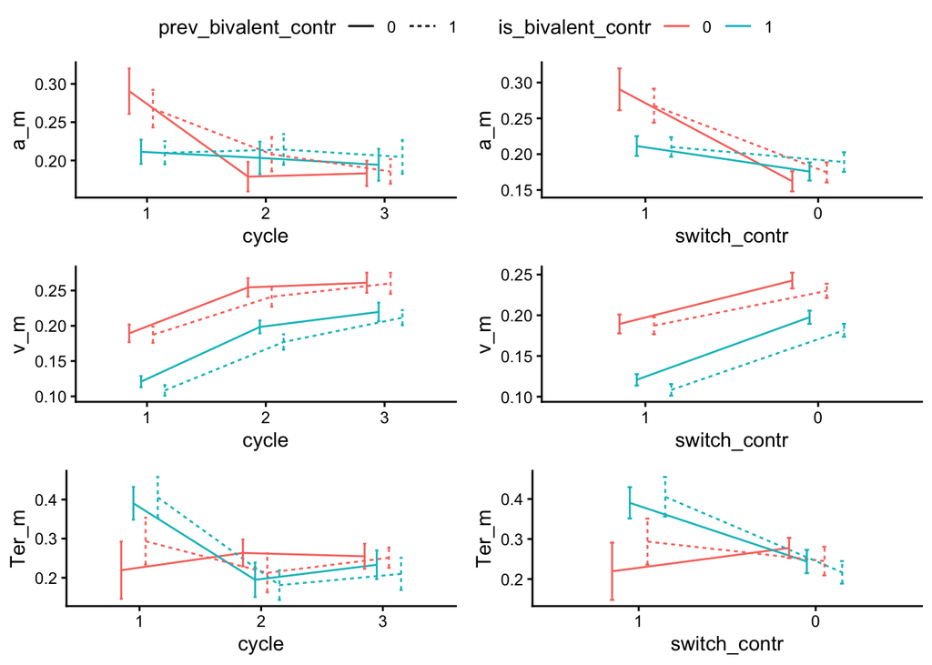

```r
plt_ddm_a <- ggplot(alt_cue_agg_ddm, aes(x = cycle, y = a_m, color = is_bivalent_contr, linetype = prev_bivalent_contr, group = interaction(is_bivalent_contr, prev_bivalent_contr)))+
  geom_line(position = pos)+
  geom_errorbar(aes(ymin = a_ci_lower, ymax = a_ci_upper), width = 0.1, position = pos)+
  theme_classic()

plt_ddm_v <- ggplot(alt_cue_agg_ddm, aes(x = cycle, y = v_m, color = is_bivalent_contr, linetype = prev_bivalent_contr, group = interaction(is_bivalent_contr, prev_bivalent_contr)))+
  geom_line(position = pos)+
  geom_errorbar(aes(ymin = v_ci_lower, ymax = v_ci_upper), width = 0.1, position = pos)+
  theme_classic()


plt_ddm_Ter <- ggplot(alt_cue_agg_ddm, aes(x = cycle, y = Ter_m, color = is_bivalent_contr, linetype = prev_bivalent_contr, group = interaction(is_bivalent_contr, prev_bivalent_contr)))+
  geom_line(position = pos)+
  geom_errorbar(aes(ymin = Ter_ci_lower, ymax = Ter_ci_upper), width = 0.1, position = pos)+
  theme_classic()

#########
plt_ddm_a_nocycle <- ggplot(alt_cue_agg_ddm_nocycle, aes(x = switch_contr, y = a_m, color = is_bivalent_contr, linetype = prev_bivalent_contr, group = interaction(is_bivalent_contr, prev_bivalent_contr)))+
  geom_line(position = pos)+
  geom_errorbar(aes(ymin = a_ci_lower, ymax = a_ci_upper), width = 0.1, position = pos)+
  scale_x_discrete(limits = c("1", "0"))+
  theme_classic()

plt_ddm_v_nocycle <- ggplot(alt_cue_agg_ddm_nocycle, aes(x = switch_contr, y = v_m, color = is_bivalent_contr, linetype = prev_bivalent_contr, group = interaction(is_bivalent_contr, prev_bivalent_contr)))+
  geom_line(position = pos)+
  geom_errorbar(aes(ymin = v_ci_lower, ymax = v_ci_upper), width = 0.1, position = pos)+
  scale_x_discrete(limits = c("1", "0"))+
  theme_classic()


plt_ddm_Ter_nocycle <- ggplot(alt_cue_agg_ddm_nocycle, aes(x = switch_contr, y = Ter_m, color = is_bivalent_contr, linetype = prev_bivalent_contr, group = interaction(is_bivalent_contr, prev_bivalent_contr)))+
  geom_line(position = pos)+
  geom_errorbar(aes(ymin = Ter_ci_lower, ymax = Ter_ci_upper), width = 0.1, position = pos)+
  scale_x_discrete(limits = c("1", "0"))+
  theme_classic()

ggpubr::ggarrange(plt_ddm_a, plt_ddm_a_nocycle,
                  plt_ddm_v, plt_ddm_v_nocycle,
                  plt_ddm_Ter, plt_ddm_Ter_nocycle, common.legend = TRUE, nrow = 3, ncol = 2)
```

### 6.2.3 Models

#### 6.2.3.1 Effect coded valence (-0.5, 0.5)

##### 6.2.3.1.1 a

```r
alt_cue_a_eff <- lmer(a ~ is_bivalent_eff * prev_bivalent_eff * switch_contr + (is_bivalent_eff + switch_contr + prev_bivalent_eff|id),
                      control = lmerControl(optimizer = "bobyqa"),
                      alt_cue_agg_ID_ddm_nocycle)
```

```
## boundary (singular) fit: see help('isSingular')
```

```r
# BASELINE MODEL
alt_cue_a_eff_baseline <- lmer(a ~ is_bivalent_eff * prev_bivalent_eff * switch_contr + (1|id),
                      control = lmerControl(optimizer = "bobyqa"),
                      alt_cue_agg_ID_ddm_nocycle)


#MODELS WITH 1 RE
alt_cue_a_eff_switch <- lmer(a ~ is_bivalent_eff * prev_bivalent_eff * switch_contr + (switch_contr|id),
                      control = lmerControl(optimizer = "bobyqa"),
                      alt_cue_agg_ID_ddm_nocycle)

alt_cue_a_eff_prev_bivalent <- lmer(a ~ is_bivalent_eff * prev_bivalent_eff * switch_contr + (prev_bivalent_eff|id),
                      control = lmerControl(optimizer = "bobyqa"),
                      alt_cue_agg_ID_ddm_nocycle)
```

```
## boundary (singular) fit: see help('isSingular')
```

```r
alt_cue_a_eff_is_bivalent <- lmer(a ~ is_bivalent_eff * prev_bivalent_eff * switch_contr + (is_bivalent_eff|id),
                      control = lmerControl(optimizer = "bobyqa"),
                      alt_cue_agg_ID_ddm_nocycle)
```

```
## boundary (singular) fit: see help('isSingular')
```

```r
#MODELS WITH 2 RE
alt_cue_a_eff_switch_is_bivalent <- lmer(a ~ is_bivalent_eff * prev_bivalent_eff * switch_contr + (switch_contr + is_bivalent_eff|id),
                      control = lmerControl(optimizer = "bobyqa"),
                      alt_cue_agg_ID_ddm_nocycle)
```

```
## boundary (singular) fit: see help('isSingular')
```

```r
alt_cue_a_eff_switch_prev_bivalent <- lmer(a ~ is_bivalent_eff * prev_bivalent_eff * switch_contr + (switch_contr + prev_bivalent_eff|id),
                      control = lmerControl(optimizer = "bobyqa"),
                      alt_cue_agg_ID_ddm_nocycle)
```

```
## boundary (singular) fit: see help('isSingular')
```

```r
alt_cue_a_eff_prev_bivalent_is_bivalent <- lmer(a ~ is_bivalent_eff * prev_bivalent_eff * switch_contr + (prev_bivalent_eff + is_bivalent_eff|id),
                      control = lmerControl(optimizer = "bobyqa"),
                      alt_cue_agg_ID_ddm_nocycle)
```

```
## boundary (singular) fit: see help('isSingular')
```

Final model:

```r
alt_cue_a_eff_final <- alt_cue_a_eff_switch

make_model_table(alt_cue_a_eff_switch)
```

| Call: lmer(formula = a ~ is_bivalent_eff * prev_bivalent_eff * switch_contr + (switch_contr \| id), data = alt_cue_agg_ID_ddm_nocycle, control = lmerControl(optimizer = "bobyqa")) Convergence: OK \| S… term | Call: lmer(formula = a ~ is_bivalent_eff * prev_bivalent_eff * switch_contr + (switch_contr \| id), data = alt_cue_agg_ID_ddm_nocycle, control = lmerControl(optimizer = "bobyqa")) Convergence: OK \| S… Estimate | Call: lmer(formula = a ~ is_bivalent_eff * prev_bivalent_eff * switch_contr + (switch_contr \| id), data = alt_cue_agg_ID_ddm_nocycle, control = lmerControl(optimizer = "bobyqa")) Convergence: OK \| S… Std. Error | Call: lmer(formula = a ~ is_bivalent_eff * prev_bivalent_eff * switch_contr + (switch_contr \| id), data = alt_cue_agg_ID_ddm_nocycle, control = lmerControl(optimizer = "bobyqa")) Convergence: OK \| S… df | Call: lmer(formula = a ~ is_bivalent_eff * prev_bivalent_eff * switch_contr + (switch_contr \| id), data = alt_cue_agg_ID_ddm_nocycle, control = lmerControl(optimizer = "bobyqa")) Convergence: OK \| S… t value | Call: lmer(formula = a ~ is_bivalent_eff * prev_bivalent_eff * switch_contr + (switch_contr \| id), data = alt_cue_agg_ID_ddm_nocycle, control = lmerControl(optimizer = "bobyqa")) Convergence: OK \| S… Pr(>\|t\|) |
| --- | --- | --- | --- | --- | --- |
| (Intercept) | 0.18 | 0.01 | 70.00 | 22.27 | 0.0000 |
| is_bivalent_eff1 | 0.01 | 0.01 | 420.00 | 1.54 | 0.1244 |
| prev_bivalent_eff1 | 0.01 | 0.01 | 420.00 | 1.41 | 0.1595 |
| switch_contr1 | 0.07 | 0.01 | 70.00 | 8.30 | 0.0000 |
| is_bivalent_eff1:prev_bivalent_eff1 | 0.00 | 0.02 | 420.00 | 0.04 | 0.9648 |
| is_bivalent_eff1:switch_contr1 | -0.08 | 0.01 | 420.00 | -6.41 | 0.0000 |
| prev_bivalent_eff1:switch_contr1 | -0.02 | 0.01 | 420.00 | -1.93 | 0.0538 |
| is_bivalent_eff1:prev_bivalent_eff1:switch_contr1 | 0.02 | 0.03 | 420.00 | 0.80 | 0.4213 |

##### 6.2.3.1.2 v

Singularity.

```r
alt_cue_v_eff <- lmer(v ~ is_bivalent_eff * prev_bivalent_eff * switch_contr + (is_bivalent_eff + prev_bivalent_eff + switch_contr|id),
                      control = lmerControl(optimizer = "bobyqa"),
                      alt_cue_agg_ID_ddm_nocycle)
```

```
## boundary (singular) fit: see help('isSingular')
```

```r
#summary(alt_cue_v)
make_model_table(alt_cue_v_eff)
```

| Call: lmer(formula = v ~ is_bivalent_eff * prev_bivalent_eff * switch_contr + (is_bivalent_eff + prev_bivalent_eff + switch_contr \| id), data = alt_cue_agg_ID_ddm_nocycle, control = lmerControl(optim… term | Call: lmer(formula = v ~ is_bivalent_eff * prev_bivalent_eff * switch_contr + (is_bivalent_eff + prev_bivalent_eff + switch_contr \| id), data = alt_cue_agg_ID_ddm_nocycle, control = lmerControl(optim… Estimate | Call: lmer(formula = v ~ is_bivalent_eff * prev_bivalent_eff * switch_contr + (is_bivalent_eff + prev_bivalent_eff + switch_contr \| id), data = alt_cue_agg_ID_ddm_nocycle, control = lmerControl(optim… Std. Error | Call: lmer(formula = v ~ is_bivalent_eff * prev_bivalent_eff * switch_contr + (is_bivalent_eff + prev_bivalent_eff + switch_contr \| id), data = alt_cue_agg_ID_ddm_nocycle, control = lmerControl(optim… df | Call: lmer(formula = v ~ is_bivalent_eff * prev_bivalent_eff * switch_contr + (is_bivalent_eff + prev_bivalent_eff + switch_contr \| id), data = alt_cue_agg_ID_ddm_nocycle, control = lmerControl(optim… t value | Call: lmer(formula = v ~ is_bivalent_eff * prev_bivalent_eff * switch_contr + (is_bivalent_eff + prev_bivalent_eff + switch_contr \| id), data = alt_cue_agg_ID_ddm_nocycle, control = lmerControl(optim… Pr(>\|t\|) |
| --- | --- | --- | --- | --- | --- |
| (Intercept) | 0.21 | 0.01 | 70.00 | 35.38 | 0.0000 |
| is_bivalent_eff1 | -0.05 | 0.01 | 165.23 | -9.31 | 0.0000 |
| prev_bivalent_eff1 | -0.01 | 0.00 | 351.78 | -3.35 | 0.0009 |
| switch_contr1 | -0.06 | 0.00 | 70.02 | -14.01 | 0.0000 |
| is_bivalent_eff1:prev_bivalent_eff1 | -0.00 | 0.01 | 350.00 | -0.40 | 0.6892 |
| is_bivalent_eff1:switch_contr1 | -0.03 | 0.01 | 350.00 | -4.47 | 0.0000 |
| prev_bivalent_eff1:switch_contr1 | 0.01 | 0.01 | 350.00 | 1.18 | 0.2378 |
| is_bivalent_eff1:prev_bivalent_eff1:switch_contr1 | -0.01 | 0.01 | 350.00 | -0.58 | 0.5642 |

```r
# BASELINE
alt_cue_v_eff_baseline <- lmer(v ~ is_bivalent_eff * prev_bivalent_eff * switch_contr + (1|id),
                               control = lmerControl(optimizer = "bobyqa"),
                               alt_cue_agg_ID_ddm_nocycle)

# MODELS WITH 1 RE
alt_cue_v_eff_is_bivalent <- lmer(v ~ is_bivalent_eff * prev_bivalent_eff * switch_contr + (is_bivalent_eff|id),
                                  control = lmerControl(optimizer = "bobyqa"),
                                  alt_cue_agg_ID_ddm_nocycle)
```

```
## boundary (singular) fit: see help('isSingular')
```

```r
alt_cue_v_eff_prev_bivalent <- lmer(v ~ is_bivalent_eff * prev_bivalent_eff * switch_contr + (prev_bivalent_eff|id),
                                    control = lmerControl(optimizer = "bobyqa"),
                                    alt_cue_agg_ID_ddm_nocycle)
```

```
## boundary (singular) fit: see help('isSingular')
```

```r
alt_cue_v_eff_switch <- lmer(v ~ is_bivalent_eff * prev_bivalent_eff * switch_contr + (switch_contr|id),
                             control = lmerControl(optimizer = "bobyqa"),
                             alt_cue_agg_ID_ddm_nocycle)


# MODELS WITH 2 RE
alt_cue_v_eff_is_bivalent_switch <- lmer(v ~ is_bivalent_eff * prev_bivalent_eff * switch_contr + (is_bivalent_eff + switch_contr|id),
                                  control = lmerControl(optimizer = "bobyqa"),
                                  alt_cue_agg_ID_ddm_nocycle)


alt_cue_v_eff_prev_bivalent_switch <- lmer(v ~ is_bivalent_eff * prev_bivalent_eff * switch_contr + (prev_bivalent_eff + switch_contr|id),
                                    control = lmerControl(optimizer = "bobyqa"),
                                    alt_cue_agg_ID_ddm_nocycle)
```

```
## boundary (singular) fit: see help('isSingular')
```

```r
alt_cue_v_eff_is_bivalent_prev_bivalent <- lmer(v ~ is_bivalent_eff * prev_bivalent_eff * switch_contr + (is_bivalent_eff + prev_bivalent_eff|id),
                             control = lmerControl(optimizer = "bobyqa"),
                             alt_cue_agg_ID_ddm_nocycle)
```

```
## boundary (singular) fit: see help('isSingular')
```

Final model:

```r
alt_cue_v_eff_final <- alt_cue_v_eff_is_bivalent_switch

make_model_table(alt_cue_v_eff_final)
```

| Call: lmer(formula = v ~ is_bivalent_eff * prev_bivalent_eff * switch_contr + (is_bivalent_eff + switch_contr \| id), data = alt_cue_agg_ID_ddm_nocycle, control = lmerControl(optimizer = "bobyqa")) Co… term | Call: lmer(formula = v ~ is_bivalent_eff * prev_bivalent_eff * switch_contr + (is_bivalent_eff + switch_contr \| id), data = alt_cue_agg_ID_ddm_nocycle, control = lmerControl(optimizer = "bobyqa")) Co… Estimate | Call: lmer(formula = v ~ is_bivalent_eff * prev_bivalent_eff * switch_contr + (is_bivalent_eff + switch_contr \| id), data = alt_cue_agg_ID_ddm_nocycle, control = lmerControl(optimizer = "bobyqa")) Co… Std. Error | Call: lmer(formula = v ~ is_bivalent_eff * prev_bivalent_eff * switch_contr + (is_bivalent_eff + switch_contr \| id), data = alt_cue_agg_ID_ddm_nocycle, control = lmerControl(optimizer = "bobyqa")) Co… df | Call: lmer(formula = v ~ is_bivalent_eff * prev_bivalent_eff * switch_contr + (is_bivalent_eff + switch_contr \| id), data = alt_cue_agg_ID_ddm_nocycle, control = lmerControl(optimizer = "bobyqa")) Co… t value | Call: lmer(formula = v ~ is_bivalent_eff * prev_bivalent_eff * switch_contr + (is_bivalent_eff + switch_contr \| id), data = alt_cue_agg_ID_ddm_nocycle, control = lmerControl(optimizer = "bobyqa")) Co… Pr(>\|t\|) |
| --- | --- | --- | --- | --- | --- |
| (Intercept) | 0.21 | 0.01 | 70.00 | 35.38 | 0.0000 |
| is_bivalent_eff1 | -0.05 | 0.01 | 162.14 | -9.32 | 0.0000 |
| prev_bivalent_eff1 | -0.01 | 0.00 | 350.00 | -3.35 | 0.0009 |
| switch_contr1 | -0.06 | 0.00 | 70.00 | -14.01 | 0.0000 |
| is_bivalent_eff1:prev_bivalent_eff1 | -0.00 | 0.01 | 350.00 | -0.40 | 0.6897 |
| is_bivalent_eff1:switch_contr1 | -0.03 | 0.01 | 350.00 | -4.46 | 0.0000 |
| prev_bivalent_eff1:switch_contr1 | 0.01 | 0.01 | 350.00 | 1.18 | 0.2385 |
| is_bivalent_eff1:prev_bivalent_eff1:switch_contr1 | -0.01 | 0.01 | 350.00 | -0.58 | 0.5648 |

##### 6.2.3.1.3 Ter

Singularity.

```r
alt_cue_Ter_eff <- lmer(Ter ~ is_bivalent_eff * prev_bivalent_eff * switch_contr + (is_bivalent_eff + prev_bivalent_eff + switch_contr|id),
                        control = lmerControl(optimizer = "bobyqa"),
                        alt_cue_agg_ID_ddm_nocycle)
```

```
## boundary (singular) fit: see help('isSingular')
```

```r
#summary(alt_cue_Ter)
make_model_table(alt_cue_Ter_eff)
```

| Call: lmer(formula = Ter ~ is_bivalent_eff * prev_bivalent_eff * switch_contr + (is_bivalent_eff + prev_bivalent_eff + switch_contr \| id), data = alt_cue_agg_ID_ddm_nocycle, control = lmerControl(opt… term | Call: lmer(formula = Ter ~ is_bivalent_eff * prev_bivalent_eff * switch_contr + (is_bivalent_eff + prev_bivalent_eff + switch_contr \| id), data = alt_cue_agg_ID_ddm_nocycle, control = lmerControl(opt… Estimate | Call: lmer(formula = Ter ~ is_bivalent_eff * prev_bivalent_eff * switch_contr + (is_bivalent_eff + prev_bivalent_eff + switch_contr \| id), data = alt_cue_agg_ID_ddm_nocycle, control = lmerControl(opt… Std. Error | Call: lmer(formula = Ter ~ is_bivalent_eff * prev_bivalent_eff * switch_contr + (is_bivalent_eff + prev_bivalent_eff + switch_contr \| id), data = alt_cue_agg_ID_ddm_nocycle, control = lmerControl(opt… df | Call: lmer(formula = Ter ~ is_bivalent_eff * prev_bivalent_eff * switch_contr + (is_bivalent_eff + prev_bivalent_eff + switch_contr \| id), data = alt_cue_agg_ID_ddm_nocycle, control = lmerControl(opt… t value | Call: lmer(formula = Ter ~ is_bivalent_eff * prev_bivalent_eff * switch_contr + (is_bivalent_eff + prev_bivalent_eff + switch_contr \| id), data = alt_cue_agg_ID_ddm_nocycle, control = lmerControl(opt… Pr(>\|t\|) |
| --- | --- | --- | --- | --- | --- |
| (Intercept) | 0.25 | 0.02 | 78.58 | 16.10 | 0.0000 |
| is_bivalent_eff1 | -0.03 | 0.03 | 138.11 | -1.15 | 0.2512 |
| prev_bivalent_eff1 | -0.03 | 0.02 | 348.88 | -1.41 | 0.1593 |
| switch_contr1 | 0.08 | 0.02 | 86.65 | 4.08 | 0.0001 |
| is_bivalent_eff1:prev_bivalent_eff1 | 0.01 | 0.04 | 420.00 | 0.13 | 0.8929 |
| is_bivalent_eff1:switch_contr1 | 0.17 | 0.03 | 420.00 | 5.90 | 0.0000 |
| prev_bivalent_eff1:switch_contr1 | 0.07 | 0.03 | 420.00 | 2.55 | 0.0113 |
| is_bivalent_eff1:prev_bivalent_eff1:switch_contr1 | -0.06 | 0.06 | 420.00 | -1.11 | 0.2690 |

Simplify.

```r
# BASELINE MODEL

alt_cue_Ter_eff_baseline <- lmer(Ter ~ is_bivalent_eff * prev_bivalent_eff * switch_contr + (1|id),
                                 control = lmerControl(optimizer = "bobyqa"),
                                 alt_cue_agg_ID_ddm_nocycle)

# MODELS WITH 1 RE

alt_cue_Ter_eff_is_bivalent <- lmer(Ter ~ is_bivalent_eff * prev_bivalent_eff * switch_contr + (is_bivalent_eff|id),
                                    control = lmerControl(optimizer = "bobyqa"),
                                    alt_cue_agg_ID_ddm_nocycle)

alt_cue_Ter_eff_prev_bivalent <- lmer(Ter ~ is_bivalent_eff * prev_bivalent_eff * switch_contr + (prev_bivalent_eff|id),
                                      control = lmerControl(optimizer = "bobyqa"),
                                      alt_cue_agg_ID_ddm_nocycle)
```

```
## boundary (singular) fit: see help('isSingular')
```

```r
alt_cue_Ter_eff_switch <- lmer(Ter ~ is_bivalent_eff * prev_bivalent_eff * switch_contr + (switch_contr|id),
                               control = lmerControl(optimizer = "bobyqa"),
                               alt_cue_agg_ID_ddm_nocycle)
```

```
## boundary (singular) fit: see help('isSingular')
```

```r
# MODELS WITH 2 RE


alt_cue_Ter_eff_is_bivalent_switch <- lmer(Ter ~ is_bivalent_eff * prev_bivalent_eff * switch_contr + (is_bivalent_eff + switch_contr|id),
                                    control = lmerControl(optimizer = "bobyqa"),
                                    alt_cue_agg_ID_ddm_nocycle)
```

```
## boundary (singular) fit: see help('isSingular')
```

```r
alt_cue_Ter_eff_prev_bivalent_switch <- lmer(Ter ~ is_bivalent_eff * prev_bivalent_eff * switch_contr + (prev_bivalent_eff + switch_contr|id),
                                      control = lmerControl(optimizer = "bobyqa"),
                                      alt_cue_agg_ID_ddm_nocycle)
```

```
## boundary (singular) fit: see help('isSingular')
```

```r
alt_cue_Ter_eff_switch_is_bivalent <- lmer(Ter ~ is_bivalent_eff * prev_bivalent_eff * switch_contr + (prev_bivalent_eff + is_bivalent_eff|id),
                               control = lmerControl(optimizer = "bobyqa"),
                               alt_cue_agg_ID_ddm_nocycle)
```

```
## boundary (singular) fit: see help('isSingular')
```

Final model:

```r
alt_cue_Ter_eff_final <- alt_cue_Ter_eff_is_bivalent

make_model_table(alt_cue_Ter_eff_final)
```

| Call: lmer(formula = Ter ~ is_bivalent_eff * prev_bivalent_eff * switch_contr + (is_bivalent_eff \| id), data = alt_cue_agg_ID_ddm_nocycle, control = lmerControl(optimizer = "bobyqa")) Convergence: OK… term | Call: lmer(formula = Ter ~ is_bivalent_eff * prev_bivalent_eff * switch_contr + (is_bivalent_eff \| id), data = alt_cue_agg_ID_ddm_nocycle, control = lmerControl(optimizer = "bobyqa")) Convergence: OK… Estimate | Call: lmer(formula = Ter ~ is_bivalent_eff * prev_bivalent_eff * switch_contr + (is_bivalent_eff \| id), data = alt_cue_agg_ID_ddm_nocycle, control = lmerControl(optimizer = "bobyqa")) Convergence: OK… Std. Error | Call: lmer(formula = Ter ~ is_bivalent_eff * prev_bivalent_eff * switch_contr + (is_bivalent_eff \| id), data = alt_cue_agg_ID_ddm_nocycle, control = lmerControl(optimizer = "bobyqa")) Convergence: OK… df | Call: lmer(formula = Ter ~ is_bivalent_eff * prev_bivalent_eff * switch_contr + (is_bivalent_eff \| id), data = alt_cue_agg_ID_ddm_nocycle, control = lmerControl(optimizer = "bobyqa")) Convergence: OK… t value | Call: lmer(formula = Ter ~ is_bivalent_eff * prev_bivalent_eff * switch_contr + (is_bivalent_eff \| id), data = alt_cue_agg_ID_ddm_nocycle, control = lmerControl(optimizer = "bobyqa")) Convergence: OK… Pr(>\|t\|) |
| --- | --- | --- | --- | --- | --- |
| (Intercept) | 0.25 | 0.02 | 95.56 | 11.88 | 0.0000 |
| is_bivalent_eff1 | -0.03 | 0.03 | 150.32 | -1.13 | 0.2599 |
| prev_bivalent_eff1 | -0.03 | 0.02 | 420.00 | -1.34 | 0.1825 |
| switch_contr1 | 0.08 | 0.02 | 420.00 | 5.14 | 0.0000 |
| is_bivalent_eff1:prev_bivalent_eff1 | 0.01 | 0.04 | 420.00 | 0.12 | 0.9009 |
| is_bivalent_eff1:switch_contr1 | 0.17 | 0.03 | 420.00 | 5.46 | 0.0000 |
| prev_bivalent_eff1:switch_contr1 | 0.07 | 0.03 | 420.00 | 2.35 | 0.0191 |
| is_bivalent_eff1:prev_bivalent_eff1:switch_contr1 | -0.06 | 0.06 | 420.00 | -1.02 | 0.3069 |

###### 6.2.3.1.3.1 individual differences

v

```r
alt_cue_agg_ID_ddm_nocycle_id <- alt_cue_agg_ID_ddm_nocycle %>%
  left_join(alt_cue_cog, by = c("id" = "ID")) %>%
  filter(!is.na(g))


alt_cue_v_eff_id <- lmer(v ~ is_bivalent_eff * prev_bivalent_eff * switch_contr * g + (prev_bivalent_eff + is_bivalent_eff + switch_contr|id),
                      control = lmerControl(optimizer = "bobyqa"),
                      alt_cue_agg_ID_ddm_nocycle_id)
```

```
## boundary (singular) fit: see help('isSingular')
```

```r
#summary(alt_cue_v)
make_model_table(alt_cue_v_eff_id)
```

| Call: lmer(formula = v ~ is_bivalent_eff * prev_bivalent_eff * switch_contr * g + (prev_bivalent_eff + is_bivalent_eff + switch_contr \| id), data = alt_cue_agg_ID_ddm_nocycle_id, control = lmerContro… term | Call: lmer(formula = v ~ is_bivalent_eff * prev_bivalent_eff * switch_contr * g + (prev_bivalent_eff + is_bivalent_eff + switch_contr \| id), data = alt_cue_agg_ID_ddm_nocycle_id, control = lmerContro… Estimate | Call: lmer(formula = v ~ is_bivalent_eff * prev_bivalent_eff * switch_contr * g + (prev_bivalent_eff + is_bivalent_eff + switch_contr \| id), data = alt_cue_agg_ID_ddm_nocycle_id, control = lmerContro… Std. Error | Call: lmer(formula = v ~ is_bivalent_eff * prev_bivalent_eff * switch_contr * g + (prev_bivalent_eff + is_bivalent_eff + switch_contr \| id), data = alt_cue_agg_ID_ddm_nocycle_id, control = lmerContro… df | Call: lmer(formula = v ~ is_bivalent_eff * prev_bivalent_eff * switch_contr * g + (prev_bivalent_eff + is_bivalent_eff + switch_contr \| id), data = alt_cue_agg_ID_ddm_nocycle_id, control = lmerContro… t value | Call: lmer(formula = v ~ is_bivalent_eff * prev_bivalent_eff * switch_contr * g + (prev_bivalent_eff + is_bivalent_eff + switch_contr \| id), data = alt_cue_agg_ID_ddm_nocycle_id, control = lmerContro… Pr(>\|t\|) |
| --- | --- | --- | --- | --- | --- |
| (Intercept) | 0.22 | 0.01 | 61.00 | 32.28 | 0.0000 |
| is_bivalent_eff1 | -0.04 | 0.01 | 138.98 | -8.25 | 0.0000 |
| prev_bivalent_eff1 | -0.01 | 0.00 | 304.53 | -2.90 | 0.0040 |
| switch_contr1 | -0.06 | 0.00 | 60.99 | -14.40 | 0.0000 |
| g | 0.00 | 0.01 | 61.00 | 0.29 | 0.7725 |
| is_bivalent_eff1:prev_bivalent_eff1 | -0.01 | 0.01 | 304.99 | -0.76 | 0.4503 |
| is_bivalent_eff1:switch_contr1 | -0.03 | 0.01 | 304.99 | -4.44 | 0.0000 |
| prev_bivalent_eff1:switch_contr1 | 0.01 | 0.01 | 304.99 | 0.96 | 0.3363 |
| is_bivalent_eff1:g | 0.00 | 0.01 | 138.98 | 0.22 | 0.8276 |
| prev_bivalent_eff1:g | -0.00 | 0.00 | 304.53 | -0.87 | 0.3877 |
| switch_contr1:g | -0.01 | 0.00 | 60.99 | -2.44 | 0.0177 |
| is_bivalent_eff1:prev_bivalent_eff1:switch_contr1 | -0.01 | 0.01 | 304.99 | -0.50 | 0.6196 |
| is_bivalent_eff1:prev_bivalent_eff1:g | 0.01 | 0.01 | 304.99 | 0.54 | 0.5868 |
| is_bivalent_eff1:switch_contr1:g | 0.00 | 0.01 | 304.99 | 0.32 | 0.7500 |
| prev_bivalent_eff1:switch_contr1:g | -0.01 | 0.01 | 304.99 | -0.91 | 0.3631 |
| is_bivalent_eff1:prev_bivalent_eff1:switch_contr1:g | -0.01 | 0.01 | 304.99 | -0.84 | 0.4008 |

#### 6.2.3.2 Contrast coded (0, 1)

##### 6.2.3.2.1 a

Singularity.

```r
alt_cue_a_contr <- lmer(a ~ is_bivalent_contr * prev_bivalent_contr * switch_contr + (is_bivalent_contr + prev_bivalent_contr + switch_contr|id),
                        control = lmerControl(optimizer = "bobyqa"),
                        alt_cue_agg_ID_ddm_nocycle)
```

```
## boundary (singular) fit: see help('isSingular')
```

```r
make_model_table(alt_cue_a_contr)
```

| Call: lmer(formula = a ~ is_bivalent_contr * prev_bivalent_contr * switch_contr + (is_bivalent_contr + prev_bivalent_contr + switch_contr \| id), data = alt_cue_agg_ID_ddm_nocycle, control = lmerContr… term | Call: lmer(formula = a ~ is_bivalent_contr * prev_bivalent_contr * switch_contr + (is_bivalent_contr + prev_bivalent_contr + switch_contr \| id), data = alt_cue_agg_ID_ddm_nocycle, control = lmerContr… Estimate | Call: lmer(formula = a ~ is_bivalent_contr * prev_bivalent_contr * switch_contr + (is_bivalent_contr + prev_bivalent_contr + switch_contr \| id), data = alt_cue_agg_ID_ddm_nocycle, control = lmerContr… Std. Error | Call: lmer(formula = a ~ is_bivalent_contr * prev_bivalent_contr * switch_contr + (is_bivalent_contr + prev_bivalent_contr + switch_contr \| id), data = alt_cue_agg_ID_ddm_nocycle, control = lmerContr… df | Call: lmer(formula = a ~ is_bivalent_contr * prev_bivalent_contr * switch_contr + (is_bivalent_contr + prev_bivalent_contr + switch_contr \| id), data = alt_cue_agg_ID_ddm_nocycle, control = lmerContr… t value | Call: lmer(formula = a ~ is_bivalent_contr * prev_bivalent_contr * switch_contr + (is_bivalent_contr + prev_bivalent_contr + switch_contr \| id), data = alt_cue_agg_ID_ddm_nocycle, control = lmerContr… Pr(>\|t\|) |
| --- | --- | --- | --- | --- | --- |
| (Intercept) | 0.16 | 0.01 | 120.19 | 13.44 | 0.0000 |
| is_bivalent_contr1 | 0.01 | 0.01 | 288.41 | 1.03 | 0.3043 |
| prev_bivalent_contr1 | 0.01 | 0.01 | 415.85 | 1.07 | 0.2856 |
| switch_contr1 | 0.13 | 0.01 | 291.22 | 9.70 | 0.0000 |
| is_bivalent_contr1:prev_bivalent_contr1 | 0.00 | 0.02 | 420.00 | 0.05 | 0.9608 |
| is_bivalent_contr1:switch_contr1 | -0.09 | 0.02 | 420.00 | -5.68 | 0.0000 |
| prev_bivalent_contr1:switch_contr1 | -0.04 | 0.02 | 420.00 | -2.16 | 0.0315 |
| is_bivalent_contr1:prev_bivalent_contr1:switch_contr1 | 0.02 | 0.02 | 420.00 | 0.90 | 0.3701 |

Simplify.

```r
# BASELINE MODEL
alt_cue_a_contr_baseline <- lmer(a ~ is_bivalent_contr * prev_bivalent_contr * switch_contr + (1|id),
                                 control = lmerControl(optimizer = "bobyqa"),
                                 alt_cue_agg_ID_ddm_nocycle)

# MODELS WITH 1 RE
alt_cue_a_contr_is_bivalent <- lmer(a ~ is_bivalent_contr * prev_bivalent_contr * switch_contr + (is_bivalent_contr|id),
                                    control = lmerControl(optimizer = "bobyqa"),
                                    alt_cue_agg_ID_ddm_nocycle)
```

```
## boundary (singular) fit: see help('isSingular')
```

```r
alt_cue_a_contr_prev_bivalent <- lmer(a ~ is_bivalent_contr * prev_bivalent_contr * switch_contr + (prev_bivalent_contr|id),
                                      control = lmerControl(optimizer = "bobyqa"),
                                      alt_cue_agg_ID_ddm_nocycle)
```

```
## boundary (singular) fit: see help('isSingular')
```

```r
alt_cue_a_contr_switch <- lmer(a ~ is_bivalent_contr * prev_bivalent_contr * switch_contr + (switch_contr|id),
                               control = lmerControl(optimizer = "bobyqa"),
                               alt_cue_agg_ID_ddm_nocycle)


# MODELS WITH 2 RE

alt_cue_a_contr_is_bivalent_switch <- lmer(a ~ is_bivalent_contr * prev_bivalent_contr * switch_contr + (is_bivalent_contr + switch_contr|id),
                                    control = lmerControl(optimizer = "bobyqa"),
                                    alt_cue_agg_ID_ddm_nocycle)
```

```
## boundary (singular) fit: see help('isSingular')
```

```r
alt_cue_a_contr_prev_bivalent_switch <- lmer(a ~ is_bivalent_contr * prev_bivalent_contr * switch_contr + (prev_bivalent_contr + switch_contr|id),
                                      control = lmerControl(optimizer = "bobyqa"),
                                      alt_cue_agg_ID_ddm_nocycle)
```

```
## boundary (singular) fit: see help('isSingular')
```

```r
alt_cue_a_contr_prev_bivalent_is_bivalent <- lmer(a ~ is_bivalent_contr * prev_bivalent_contr * switch_contr + (is_bivalent_contr + prev_bivalent_contr |id),
                               control = lmerControl(optimizer = "bobyqa"),
                               alt_cue_agg_ID_ddm_nocycle)
```

```
## boundary (singular) fit: see help('isSingular')
```

Final model:

```r
alt_cue_a_contr_final <- alt_cue_a_contr_switch
make_model_table(alt_cue_a_contr_final)
```

| Call: lmer(formula = a ~ is_bivalent_contr * prev_bivalent_contr * switch_contr + (switch_contr \| id), data = alt_cue_agg_ID_ddm_nocycle, control = lmerControl(optimizer = "bobyqa")) Convergence: OK … term | Call: lmer(formula = a ~ is_bivalent_contr * prev_bivalent_contr * switch_contr + (switch_contr \| id), data = alt_cue_agg_ID_ddm_nocycle, control = lmerControl(optimizer = "bobyqa")) Convergence: OK … Estimate | Call: lmer(formula = a ~ is_bivalent_contr * prev_bivalent_contr * switch_contr + (switch_contr \| id), data = alt_cue_agg_ID_ddm_nocycle, control = lmerControl(optimizer = "bobyqa")) Convergence: OK … Std. Error | Call: lmer(formula = a ~ is_bivalent_contr * prev_bivalent_contr * switch_contr + (switch_contr \| id), data = alt_cue_agg_ID_ddm_nocycle, control = lmerControl(optimizer = "bobyqa")) Convergence: OK … df | Call: lmer(formula = a ~ is_bivalent_contr * prev_bivalent_contr * switch_contr + (switch_contr \| id), data = alt_cue_agg_ID_ddm_nocycle, control = lmerControl(optimizer = "bobyqa")) Convergence: OK … t value | Call: lmer(formula = a ~ is_bivalent_contr * prev_bivalent_contr * switch_contr + (switch_contr \| id), data = alt_cue_agg_ID_ddm_nocycle, control = lmerControl(optimizer = "bobyqa")) Convergence: OK … Pr(>\|t\|) |
| --- | --- | --- | --- | --- | --- |
| (Intercept) | 0.16 | 0.01 | 240.14 | 14.56 | 0.0000 |
| is_bivalent_contr1 | 0.01 | 0.01 | 420.00 | 1.06 | 0.2909 |
| prev_bivalent_contr1 | 0.01 | 0.01 | 420.00 | 0.97 | 0.3349 |
| switch_contr1 | 0.13 | 0.01 | 352.70 | 9.21 | 0.0000 |
| is_bivalent_contr1:prev_bivalent_contr1 | 0.00 | 0.02 | 420.00 | 0.04 | 0.9648 |
| is_bivalent_contr1:switch_contr1 | -0.09 | 0.02 | 420.00 | -5.10 | 0.0000 |
| prev_bivalent_contr1:switch_contr1 | -0.04 | 0.02 | 420.00 | -1.94 | 0.0535 |
| is_bivalent_contr1:prev_bivalent_contr1:switch_contr1 | 0.02 | 0.03 | 420.00 | 0.80 | 0.4213 |

##### 6.2.3.2.2 v

Singular.

```r
alt_cue_v_contr <- lmer(v ~ is_bivalent_contr * prev_bivalent_contr * switch_contr + (is_bivalent_contr + prev_bivalent_contr + switch_contr|id),
                        control = lmerControl(optimizer = "bobyqa"),
                        alt_cue_agg_ID_ddm_nocycle)
```

```
## boundary (singular) fit: see help('isSingular')
```

```r
make_model_table(alt_cue_v_contr)
```

| Call: lmer(formula = v ~ is_bivalent_contr * prev_bivalent_contr * switch_contr + (is_bivalent_contr + prev_bivalent_contr + switch_contr \| id), data = alt_cue_agg_ID_ddm_nocycle, control = lmerContr… term | Call: lmer(formula = v ~ is_bivalent_contr * prev_bivalent_contr * switch_contr + (is_bivalent_contr + prev_bivalent_contr + switch_contr \| id), data = alt_cue_agg_ID_ddm_nocycle, control = lmerContr… Estimate | Call: lmer(formula = v ~ is_bivalent_contr * prev_bivalent_contr * switch_contr + (is_bivalent_contr + prev_bivalent_contr + switch_contr \| id), data = alt_cue_agg_ID_ddm_nocycle, control = lmerContr… Std. Error | Call: lmer(formula = v ~ is_bivalent_contr * prev_bivalent_contr * switch_contr + (is_bivalent_contr + prev_bivalent_contr + switch_contr \| id), data = alt_cue_agg_ID_ddm_nocycle, control = lmerContr… df | Call: lmer(formula = v ~ is_bivalent_contr * prev_bivalent_contr * switch_contr + (is_bivalent_contr + prev_bivalent_contr + switch_contr \| id), data = alt_cue_agg_ID_ddm_nocycle, control = lmerContr… t value | Call: lmer(formula = v ~ is_bivalent_contr * prev_bivalent_contr * switch_contr + (is_bivalent_contr + prev_bivalent_contr + switch_contr \| id), data = alt_cue_agg_ID_ddm_nocycle, control = lmerContr… Pr(>\|t\|) |
| --- | --- | --- | --- | --- | --- |
| (Intercept) | 0.24 | 0.01 | 94.59 | 30.26 | 0.0000 |
| is_bivalent_contr1 | -0.05 | 0.01 | 323.30 | -6.83 | 0.0000 |
| prev_bivalent_contr1 | -0.01 | 0.01 | 360.22 | -2.09 | 0.0373 |
| switch_contr1 | -0.05 | 0.01 | 291.70 | -7.81 | 0.0000 |
| is_bivalent_contr1:prev_bivalent_contr1 | -0.00 | 0.01 | 350.00 | -0.40 | 0.6892 |
| is_bivalent_contr1:switch_contr1 | -0.02 | 0.01 | 350.00 | -2.75 | 0.0062 |
| prev_bivalent_contr1:switch_contr1 | 0.01 | 0.01 | 350.00 | 1.24 | 0.2142 |
| is_bivalent_contr1:prev_bivalent_contr1:switch_contr1 | -0.01 | 0.01 | 350.00 | -0.58 | 0.5642 |

```r
# BASELINE MODEL
alt_cue_v_contr_baseline <- lmer(v ~ is_bivalent_contr * prev_bivalent_contr * switch_contr + (1|id),
                                 control = lmerControl(optimizer = "bobyqa"),
                                 alt_cue_agg_ID_ddm_nocycle)

# MODELS WITH 1 RE
alt_cue_v_contr_is_bivalent <- lmer(v ~ is_bivalent_contr * prev_bivalent_contr * switch_contr + (is_bivalent_contr|id),
                                    control = lmerControl(optimizer = "bobyqa"),
                                    alt_cue_agg_ID_ddm_nocycle)
```

```
## boundary (singular) fit: see help('isSingular')
```

```r
alt_cue_v_contr_prev_bivalent <- lmer(v ~ is_bivalent_contr * prev_bivalent_contr * switch_contr + (prev_bivalent_contr|id),
                                      control = lmerControl(optimizer = "bobyqa"),
                                      alt_cue_agg_ID_ddm_nocycle)
```

```
## boundary (singular) fit: see help('isSingular')
```

```r
alt_cue_v_contr_switch <- lmer(v ~ is_bivalent_contr * prev_bivalent_contr * switch_contr + (switch_contr|id),
                               control = lmerControl(optimizer = "bobyqa"),
                               alt_cue_agg_ID_ddm_nocycle)


# MODELS WITH 2 RE

alt_cue_v_contr_is_bivalent_switch <- lmer(v ~ is_bivalent_contr * prev_bivalent_contr * switch_contr + (is_bivalent_contr + switch_contr|id),
                                    control = lmerControl(optimizer = "bobyqa"),
                                    alt_cue_agg_ID_ddm_nocycle)

alt_cue_v_contr_prev_bivalent_switch <- lmer(v ~ is_bivalent_contr * prev_bivalent_contr * switch_contr + (prev_bivalent_contr + switch_contr|id),
                                      control = lmerControl(optimizer = "bobyqa"),
                                      alt_cue_agg_ID_ddm_nocycle)
```

```
## boundary (singular) fit: see help('isSingular')
```

```r
alt_cue_v_contr_prev_bivalent_is_bivalent <- lmer(v ~ is_bivalent_contr * prev_bivalent_contr * switch_contr + (is_bivalent_contr + prev_bivalent_contr |id),
                               control = lmerControl(optimizer = "bobyqa"),
                               alt_cue_agg_ID_ddm_nocycle)
```

```
## boundary (singular) fit: see help('isSingular')
```

```r
alt_cue_v_contr_final <- alt_cue_v_contr_is_bivalent_switch


make_model_table(alt_cue_v_contr_final)
```

| Call: lmer(formula = v ~ is_bivalent_contr * prev_bivalent_contr * switch_contr + (is_bivalent_contr + switch_contr \| id), data = alt_cue_agg_ID_ddm_nocycle, control = lmerControl(optimizer = "bobyqa… term | Call: lmer(formula = v ~ is_bivalent_contr * prev_bivalent_contr * switch_contr + (is_bivalent_contr + switch_contr \| id), data = alt_cue_agg_ID_ddm_nocycle, control = lmerControl(optimizer = "bobyqa… Estimate | Call: lmer(formula = v ~ is_bivalent_contr * prev_bivalent_contr * switch_contr + (is_bivalent_contr + switch_contr \| id), data = alt_cue_agg_ID_ddm_nocycle, control = lmerControl(optimizer = "bobyqa… Std. Error | Call: lmer(formula = v ~ is_bivalent_contr * prev_bivalent_contr * switch_contr + (is_bivalent_contr + switch_contr \| id), data = alt_cue_agg_ID_ddm_nocycle, control = lmerControl(optimizer = "bobyqa… df | Call: lmer(formula = v ~ is_bivalent_contr * prev_bivalent_contr * switch_contr + (is_bivalent_contr + switch_contr \| id), data = alt_cue_agg_ID_ddm_nocycle, control = lmerControl(optimizer = "bobyqa… t value | Call: lmer(formula = v ~ is_bivalent_contr * prev_bivalent_contr * switch_contr + (is_bivalent_contr + switch_contr \| id), data = alt_cue_agg_ID_ddm_nocycle, control = lmerControl(optimizer = "bobyqa… Pr(>\|t\|) |
| --- | --- | --- | --- | --- | --- |
| (Intercept) | 0.24 | 0.01 | 102.95 | 30.40 | 0.0000 |
| is_bivalent_contr1 | -0.05 | 0.01 | 324.60 | -6.83 | 0.0000 |
| prev_bivalent_contr1 | -0.01 | 0.01 | 350.00 | -2.09 | 0.0375 |
| switch_contr1 | -0.05 | 0.01 | 292.41 | -7.80 | 0.0000 |
| is_bivalent_contr1:prev_bivalent_contr1 | -0.00 | 0.01 | 350.00 | -0.40 | 0.6897 |
| is_bivalent_contr1:switch_contr1 | -0.02 | 0.01 | 350.00 | -2.75 | 0.0063 |
| prev_bivalent_contr1:switch_contr1 | 0.01 | 0.01 | 350.00 | 1.24 | 0.2150 |
| is_bivalent_contr1:prev_bivalent_contr1:switch_contr1 | -0.01 | 0.01 | 350.00 | -0.58 | 0.5648 |

##### 6.2.3.2.3 Ter

Singular.

```r
alt_cue_Ter_contr <- lmer(Ter ~ is_bivalent_contr * prev_bivalent_contr * switch_contr + (is_bivalent_contr + prev_bivalent_contr + switch_contr|id),
                          control = lmerControl(optimizer = "bobyqa"),
                          alt_cue_agg_ID_ddm_nocycle)
```

```
## boundary (singular) fit: see help('isSingular')
```

```r
make_model_table(alt_cue_Ter_contr)
```

| Call: lmer(formula = Ter ~ is_bivalent_contr * prev_bivalent_contr * switch_contr + (is_bivalent_contr + prev_bivalent_contr + switch_contr \| id), data = alt_cue_agg_ID_ddm_nocycle, control = lmerCon… term | Call: lmer(formula = Ter ~ is_bivalent_contr * prev_bivalent_contr * switch_contr + (is_bivalent_contr + prev_bivalent_contr + switch_contr \| id), data = alt_cue_agg_ID_ddm_nocycle, control = lmerCon… Estimate | Call: lmer(formula = Ter ~ is_bivalent_contr * prev_bivalent_contr * switch_contr + (is_bivalent_contr + prev_bivalent_contr + switch_contr \| id), data = alt_cue_agg_ID_ddm_nocycle, control = lmerCon… Std. Error | Call: lmer(formula = Ter ~ is_bivalent_contr * prev_bivalent_contr * switch_contr + (is_bivalent_contr + prev_bivalent_contr + switch_contr \| id), data = alt_cue_agg_ID_ddm_nocycle, control = lmerCon… df | Call: lmer(formula = Ter ~ is_bivalent_contr * prev_bivalent_contr * switch_contr + (is_bivalent_contr + prev_bivalent_contr + switch_contr \| id), data = alt_cue_agg_ID_ddm_nocycle, control = lmerCon… t value | Call: lmer(formula = Ter ~ is_bivalent_contr * prev_bivalent_contr * switch_contr + (is_bivalent_contr + prev_bivalent_contr + switch_contr \| id), data = alt_cue_agg_ID_ddm_nocycle, control = lmerCon… Pr(>\|t\|) |
| --- | --- | --- | --- | --- | --- |
| (Intercept) | 0.28 | 0.03 | 142.04 | 10.22 | 0.0000 |
| is_bivalent_contr1 | -0.03 | 0.03 | 279.29 | -1.00 | 0.3198 |
| prev_bivalent_contr1 | -0.03 | 0.03 | 421.65 | -1.10 | 0.2705 |
| switch_contr1 | -0.06 | 0.03 | 320.27 | -1.81 | 0.0710 |
| is_bivalent_contr1:prev_bivalent_contr1 | 0.01 | 0.04 | 420.00 | 0.13 | 0.8929 |
| is_bivalent_contr1:switch_contr1 | 0.20 | 0.04 | 420.00 | 4.96 | 0.0000 |
| prev_bivalent_contr1:switch_contr1 | 0.11 | 0.04 | 420.00 | 2.58 | 0.0101 |
| is_bivalent_contr1:prev_bivalent_contr1:switch_contr1 | -0.06 | 0.06 | 420.00 | -1.11 | 0.2690 |

Simplify. Only current bivalent random slope model works.

```r
# BASELINE MODEL
alt_cue_Ter_contr_baseline <- lmer(Ter ~ is_bivalent_contr * prev_bivalent_contr * switch_contr + (1|id),
                                 control = lmerControl(optimizer = "bobyqa"),
                                 alt_cue_agg_ID_ddm_nocycle)

# MODELS WITH 1 RE
alt_cue_Ter_contr_is_bivalent <- lmer(Ter ~ is_bivalent_contr * prev_bivalent_contr * switch_contr + (is_bivalent_contr|id),
                                    control = lmerControl(optimizer = "bobyqa"),
                                    alt_cue_agg_ID_ddm_nocycle)

alt_cue_Ter_contr_prev_bivalent <- lmer(Ter ~ is_bivalent_contr * prev_bivalent_contr * switch_contr + (prev_bivalent_contr|id),
                                      control = lmerControl(optimizer = "bobyqa"),
                                      alt_cue_agg_ID_ddm_nocycle)
```

```
## boundary (singular) fit: see help('isSingular')
```

```r
alt_cue_Ter_contr_switch <- lmer(Ter ~ is_bivalent_contr * prev_bivalent_contr * switch_contr + (switch_contr|id),
                               control = lmerControl(optimizer = "bobyqa"),
                               alt_cue_agg_ID_ddm_nocycle)
```

```
## boundary (singular) fit: see help('isSingular')
```

```r
# MODELS WITH 2 RE

alt_cue_Ter_contr_is_bivalent_switch <- lmer(Ter ~ is_bivalent_contr * prev_bivalent_contr * switch_contr + (is_bivalent_contr + switch_contr|id),
                                    control = lmerControl(optimizer = "bobyqa"),
                                    alt_cue_agg_ID_ddm_nocycle)
```

```
## boundary (singular) fit: see help('isSingular')
```

```r
alt_cue_Ter_contr_prev_bivalent_switch <- lmer(Ter ~ is_bivalent_contr * prev_bivalent_contr * switch_contr + (prev_bivalent_contr + switch_contr|id),
                                      control = lmerControl(optimizer = "bobyqa"),
                                      alt_cue_agg_ID_ddm_nocycle)
```

```
## boundary (singular) fit: see help('isSingular')
```

```r
alt_cue_Ter_contr_prev_bivalent_is_bivalent <- lmer(Ter ~ is_bivalent_contr * prev_bivalent_contr * switch_contr + (is_bivalent_contr + prev_bivalent_contr |id),
                               control = lmerControl(optimizer = "bobyqa"),
                               alt_cue_agg_ID_ddm_nocycle)
```

```
## boundary (singular) fit: see help('isSingular')
```

```r
alt_cue_v_contr_final <- alt_cue_Ter_contr_is_bivalent


make_model_table(alt_cue_v_contr_final)
```

| Call: lmer(formula = Ter ~ is_bivalent_contr * prev_bivalent_contr * switch_contr + (is_bivalent_contr \| id), data = alt_cue_agg_ID_ddm_nocycle, control = lmerControl(optimizer = "bobyqa")) Convergen… term | Call: lmer(formula = Ter ~ is_bivalent_contr * prev_bivalent_contr * switch_contr + (is_bivalent_contr \| id), data = alt_cue_agg_ID_ddm_nocycle, control = lmerControl(optimizer = "bobyqa")) Convergen… Estimate | Call: lmer(formula = Ter ~ is_bivalent_contr * prev_bivalent_contr * switch_contr + (is_bivalent_contr \| id), data = alt_cue_agg_ID_ddm_nocycle, control = lmerControl(optimizer = "bobyqa")) Convergen… Std. Error | Call: lmer(formula = Ter ~ is_bivalent_contr * prev_bivalent_contr * switch_contr + (is_bivalent_contr \| id), data = alt_cue_agg_ID_ddm_nocycle, control = lmerControl(optimizer = "bobyqa")) Convergen… df | Call: lmer(formula = Ter ~ is_bivalent_contr * prev_bivalent_contr * switch_contr + (is_bivalent_contr \| id), data = alt_cue_agg_ID_ddm_nocycle, control = lmerControl(optimizer = "bobyqa")) Convergen… t value | Call: lmer(formula = Ter ~ is_bivalent_contr * prev_bivalent_contr * switch_contr + (is_bivalent_contr \| id), data = alt_cue_agg_ID_ddm_nocycle, control = lmerControl(optimizer = "bobyqa")) Convergen… Pr(>\|t\|) |
| --- | --- | --- | --- | --- | --- |
| (Intercept) | 0.28 | 0.03 | 153.65 | 8.35 | 0.0000 |
| is_bivalent_contr1 | -0.03 | 0.04 | 316.12 | -0.96 | 0.3399 |
| prev_bivalent_contr1 | -0.03 | 0.03 | 420.00 | -1.03 | 0.3025 |
| switch_contr1 | -0.06 | 0.03 | 420.00 | -1.84 | 0.0658 |
| is_bivalent_contr1:prev_bivalent_contr1 | 0.01 | 0.04 | 420.00 | 0.12 | 0.9009 |
| is_bivalent_contr1:switch_contr1 | 0.20 | 0.04 | 420.00 | 4.58 | 0.0000 |
| prev_bivalent_contr1:switch_contr1 | 0.11 | 0.04 | 420.00 | 2.39 | 0.0174 |
| is_bivalent_contr1:prev_bivalent_contr1:switch_contr1 | -0.06 | 0.06 | 420.00 | -1.02 | 0.3069 |

# 7 RT residual analysis

## 7.1 Effect coded valence (-0.5, 0.5)

### 7.1.1 Added subject intercepts

```r
#For these analyses, we need to center the RTs:

alt_cue <- alt_cue %>%
  ungroup() %>%
  mutate(time_log_res_w_s_int_c = time_log_res_w_s_int - mean(time_log_res_w_s_int, na.rm = TRUE),
         lag1_time_log_res_w_s_int_c = lag1_time_log_res_w_s_int - mean(lag1_time_log_res_w_s_int, na.rm = TRUE))

alt_cue_rt_log_resrt_eff_w_s_int <- xfun::cache_rds({
  lmer(time_log_res_w_s_int_c ~ is_bivalent_eff * prev_bivalent_eff * switch_contr * lag1_time_log_res_w_s_int_c + (is_bivalent_eff + switch_contr + prev_bivalent_eff + lag1_time_log_res_w_s_int_c | id),
       control = lmerControl(optimizer = "bobyqa"),
       alt_cue %>%
         filter(filter_correct == 0))
}, dir = "dominik/models/", file = "alt_cue_rt_log_resrt_eff_w_s_int.RDS", rerun = rerun_all)

make_model_table(alt_cue_rt_log_resrt_eff_w_s_int)
```

| Call: lmer(formula = time_log_res_w_s_int_c ~ is_bivalent_eff * prev_bivalent_eff * switch_contr * lag1_time_log_res_w_s_int_c + (is_bivalent_eff + switch_contr + prev_bivalent_eff + lag1_time_log_res… term | Call: lmer(formula = time_log_res_w_s_int_c ~ is_bivalent_eff * prev_bivalent_eff * switch_contr * lag1_time_log_res_w_s_int_c + (is_bivalent_eff + switch_contr + prev_bivalent_eff + lag1_time_log_res… Estimate | Call: lmer(formula = time_log_res_w_s_int_c ~ is_bivalent_eff * prev_bivalent_eff * switch_contr * lag1_time_log_res_w_s_int_c + (is_bivalent_eff + switch_contr + prev_bivalent_eff + lag1_time_log_res… Std. Error | Call: lmer(formula = time_log_res_w_s_int_c ~ is_bivalent_eff * prev_bivalent_eff * switch_contr * lag1_time_log_res_w_s_int_c + (is_bivalent_eff + switch_contr + prev_bivalent_eff + lag1_time_log_res… df | Call: lmer(formula = time_log_res_w_s_int_c ~ is_bivalent_eff * prev_bivalent_eff * switch_contr * lag1_time_log_res_w_s_int_c + (is_bivalent_eff + switch_contr + prev_bivalent_eff + lag1_time_log_res… t value | Call: lmer(formula = time_log_res_w_s_int_c ~ is_bivalent_eff * prev_bivalent_eff * switch_contr * lag1_time_log_res_w_s_int_c + (is_bivalent_eff + switch_contr + prev_bivalent_eff + lag1_time_log_res… Pr(>\|t\|) |
| --- | --- | --- | --- | --- | --- |
| (Intercept) | -0.16 | 0.02 | 69.33 | -9.54 | 0.0000 |
| is_bivalent_eff1 | 0.09 | 0.01 | 100.81 | 12.44 | 0.0000 |
| prev_bivalent_eff1 | 0.03 | 0.00 | 5,489.09 | 6.53 | 0.0000 |
| switch_contr1 | 0.49 | 0.02 | 71.04 | 27.67 | 0.0000 |
| lag1_time_log_res_w_s_int_c | 0.06 | 0.01 | 86.07 | 7.71 | 0.0000 |
| is_bivalent_eff1:prev_bivalent_eff1 | 0.00 | 0.01 | 34,666.56 | 0.39 | 0.6960 |
| is_bivalent_eff1:switch_contr1 | 0.04 | 0.01 | 34,650.51 | 4.25 | 0.0000 |
| prev_bivalent_eff1:switch_contr1 | -0.03 | 0.01 | 34,901.58 | -3.28 | 0.0010 |
| is_bivalent_eff1:lag1_time_log_res_w_s_int_c | 0.03 | 0.01 | 16,088.14 | 3.06 | 0.0022 |
| prev_bivalent_eff1:lag1_time_log_res_w_s_int_c | 0.02 | 0.01 | 34,579.29 | 1.81 | 0.0703 |
| switch_contr1:lag1_time_log_res_w_s_int_c | 0.07 | 0.01 | 32,528.05 | 5.82 | 0.0000 |
| is_bivalent_eff1:prev_bivalent_eff1:switch_contr1 | 0.02 | 0.02 | 35,021.61 | 1.06 | 0.2912 |
| is_bivalent_eff1:prev_bivalent_eff1:lag1_time_log_res_w_s_int_c | -0.00 | 0.02 | 34,806.43 | -0.18 | 0.8545 |
| is_bivalent_eff1:switch_contr1:lag1_time_log_res_w_s_int_c | -0.01 | 0.02 | 34,798.12 | -0.48 | 0.6315 |
| prev_bivalent_eff1:switch_contr1:lag1_time_log_res_w_s_int_c | -0.10 | 0.02 | 34,980.22 | -4.51 | 0.0000 |
| is_bivalent_eff1:prev_bivalent_eff1:switch_contr1:lag1_time_log_res_w_s_int_c | 0.03 | 0.04 | 35,040.73 | 0.64 | 0.5202 |

Only model that fails is the model with the previous bivalence factor.

```r
# BASELINE MODEL

alt_cue_rt_log_resrt_eff_w_s_int_baseline <- xfun::cache_rds({
  lmer(time_log_res_w_s_int_c ~ is_bivalent_eff * prev_bivalent_eff * switch_contr * lag1_time_log_res_w_s_int_c + (lag1_time_log_res_w_s_int_c | id),
       control = lmerControl(optimizer = "bobyqa"),
       alt_cue %>%
         filter(filter_correct == 0))
}, dir = "dominik/models/", file = "alt_cue_rt_log_resrt_eff_w_s_int_baseline.RDS", rerun = rerun_all)


# MODELS WITH 1 RE
alt_cue_rt_log_resrt_eff_w_s_int_is_bivalent <- xfun::cache_rds({
  lmer(time_log_res_w_s_int_c ~ is_bivalent_eff * prev_bivalent_eff * switch_contr * lag1_time_log_res_w_s_int_c + (lag1_time_log_res_w_s_int_c + is_bivalent_eff| id),
       control = lmerControl(optimizer = "bobyqa"),
       alt_cue %>%
         filter(filter_correct == 0))
}, dir = "dominik/models/", file = "alt_cue_rt_log_resrt_eff_w_s_int_is_bivalent.RDS", rerun = rerun_all)


alt_cue_rt_log_resrt_eff_w_s_int_prev_bivalent <- xfun::cache_rds({
  lmer(time_log_res_w_s_int_c ~ is_bivalent_eff * prev_bivalent_eff * switch_contr * lag1_time_log_res_w_s_int_c + (lag1_time_log_res_w_s_int_c  + prev_bivalent_eff| id),
       control = lmerControl(optimizer = "bobyqa"),
       alt_cue %>%
         filter(filter_correct == 0))
}, dir = "dominik/models/", file = "alt_cue_rt_log_resrt_eff_w_s_int_prev_bivalent.RDS", rerun = rerun_all)

alt_cue_rt_log_resrt_eff_w_s_int_switch <- xfun::cache_rds({
  lmer(time_log_res_w_s_int_c ~ is_bivalent_eff * prev_bivalent_eff * switch_contr * lag1_time_log_res_w_s_int_c + (lag1_time_log_res_w_s_int_c + switch_contr| id),
       control = lmerControl(optimizer = "bobyqa"),
       alt_cue %>%
         filter(filter_correct == 0))
}, dir = "dominik/models/", file = "alt_cue_rt_log_resrt_eff_w_s_int_switch.RDS", rerun = rerun_all)

#MODELS WITH 2 RE

alt_cue_rt_log_resrt_eff_w_s_int_is_bivalent_prev_bivalent <- xfun::cache_rds({
  lmer(time_log_res_w_s_int_c ~ is_bivalent_eff * prev_bivalent_eff * switch_contr * lag1_time_log_res_w_s_int_c + (lag1_time_log_res_w_s_int_c + is_bivalent_eff + prev_bivalent_eff| id),
       control = lmerControl(optimizer = "bobyqa"),
       alt_cue %>%
         filter(filter_correct == 0))
}, dir = "dominik/models/", file = "alt_cue_rt_log_resrt_eff_w_s_int_is_bivalent_prev_bivalent.RDS", rerun = rerun_all)


alt_cue_rt_log_resrt_eff_w_s_int_prev_bivalent_switch <- xfun::cache_rds({
  lmer(time_log_res_w_s_int_c ~ is_bivalent_eff * prev_bivalent_eff * switch_contr * lag1_time_log_res_w_s_int_c + (lag1_time_log_res_w_s_int_c  + switch_contr + prev_bivalent_eff| id),
       control = lmerControl(optimizer = "bobyqa"),
       alt_cue %>%
         filter(filter_correct == 0))
}, dir = "dominik/models/", file = "alt_cue_rt_log_resrt_eff_w_s_int_prev_bivalent_switch.RDS", rerun = rerun_all)

alt_cue_rt_log_resrt_eff_w_s_int_is_bivalent_switch <- xfun::cache_rds({
  lmer(time_log_res_w_s_int_c ~ is_bivalent_eff * prev_bivalent_eff * switch_contr * lag1_time_log_res_w_s_int_c + (lag1_time_log_res_w_s_int_c + switch_contr + is_bivalent_eff| id),
       control = lmerControl(optimizer = "bobyqa"),
       alt_cue %>%
         filter(filter_correct == 0))
}, dir = "dominik/models/", file = "alt_cue_rt_log_resrt_eff_w_s_int_is_bivalent_switch.RDS", rerun = rerun_all)
```

Final model:

```r
alt_cue_rt_log_resrt_eff_w_s_int_final <- alt_cue_rt_log_resrt_eff_w_s_int_is_bivalent_switch
make_model_table(alt_cue_rt_log_resrt_eff_w_s_int_final)
```

| Call: lmer(formula = time_log_res_w_s_int_c ~ is_bivalent_eff * prev_bivalent_eff * switch_contr * lag1_time_log_res_w_s_int_c + (lag1_time_log_res_w_s_int_c + switch_contr + is_bivalent_eff \| id), d… term | Call: lmer(formula = time_log_res_w_s_int_c ~ is_bivalent_eff * prev_bivalent_eff * switch_contr * lag1_time_log_res_w_s_int_c + (lag1_time_log_res_w_s_int_c + switch_contr + is_bivalent_eff \| id), d… Estimate | Call: lmer(formula = time_log_res_w_s_int_c ~ is_bivalent_eff * prev_bivalent_eff * switch_contr * lag1_time_log_res_w_s_int_c + (lag1_time_log_res_w_s_int_c + switch_contr + is_bivalent_eff \| id), d… Std. Error | Call: lmer(formula = time_log_res_w_s_int_c ~ is_bivalent_eff * prev_bivalent_eff * switch_contr * lag1_time_log_res_w_s_int_c + (lag1_time_log_res_w_s_int_c + switch_contr + is_bivalent_eff \| id), d… df | Call: lmer(formula = time_log_res_w_s_int_c ~ is_bivalent_eff * prev_bivalent_eff * switch_contr * lag1_time_log_res_w_s_int_c + (lag1_time_log_res_w_s_int_c + switch_contr + is_bivalent_eff \| id), d… t value | Call: lmer(formula = time_log_res_w_s_int_c ~ is_bivalent_eff * prev_bivalent_eff * switch_contr * lag1_time_log_res_w_s_int_c + (lag1_time_log_res_w_s_int_c + switch_contr + is_bivalent_eff \| id), d… Pr(>\|t\|) |
| --- | --- | --- | --- | --- | --- |
| (Intercept) | -0.16 | 0.02 | 69.34 | -9.54 | 0.0000 |
| is_bivalent_eff1 | 0.09 | 0.01 | 101.12 | 12.45 | 0.0000 |
| prev_bivalent_eff1 | 0.03 | 0.00 | 35,047.29 | 6.53 | 0.0000 |
| switch_contr1 | 0.49 | 0.02 | 71.05 | 27.66 | 0.0000 |
| lag1_time_log_res_w_s_int_c | 0.06 | 0.01 | 86.47 | 7.71 | 0.0000 |
| is_bivalent_eff1:prev_bivalent_eff1 | 0.00 | 0.01 | 35,047.68 | 0.36 | 0.7222 |
| is_bivalent_eff1:switch_contr1 | 0.04 | 0.01 | 34,650.68 | 4.25 | 0.0000 |
| prev_bivalent_eff1:switch_contr1 | -0.03 | 0.01 | 35,023.18 | -3.18 | 0.0015 |
| is_bivalent_eff1:lag1_time_log_res_w_s_int_c | 0.03 | 0.01 | 16,054.65 | 3.06 | 0.0022 |
| prev_bivalent_eff1:lag1_time_log_res_w_s_int_c | 0.02 | 0.01 | 34,780.88 | 2.09 | 0.0370 |
| switch_contr1:lag1_time_log_res_w_s_int_c | 0.07 | 0.01 | 32,605.47 | 5.81 | 0.0000 |
| is_bivalent_eff1:prev_bivalent_eff1:switch_contr1 | 0.02 | 0.02 | 35,023.68 | 1.07 | 0.2839 |
| is_bivalent_eff1:prev_bivalent_eff1:lag1_time_log_res_w_s_int_c | -0.00 | 0.02 | 34,831.97 | -0.20 | 0.8419 |
| is_bivalent_eff1:switch_contr1:lag1_time_log_res_w_s_int_c | -0.01 | 0.02 | 34,797.02 | -0.48 | 0.6313 |
| prev_bivalent_eff1:switch_contr1:lag1_time_log_res_w_s_int_c | -0.10 | 0.02 | 35,006.09 | -4.47 | 0.0000 |
| is_bivalent_eff1:prev_bivalent_eff1:switch_contr1:lag1_time_log_res_w_s_int_c | 0.03 | 0.04 | 35,045.27 | 0.65 | 0.5156 |

```r
preds <- emmeans::emmeans(alt_cue_rt_log_resrt_eff_w_s_int_final, ~ is_bivalent_eff * prev_bivalent_eff * switch_contr * lag1_time_log_res_w_s_int_c, type = "response",
                          at = list(is_bivalent_eff = factor(c(0, 1)),
                                    prev_bivalent_eff = factor(c(0, 1)),
                                    switch_contr = factor(c(0, 1)),
                                    lag1_time_log_res_w_s_int_c = c(-1.5, 1.5))) %>%
  as.data.frame() %>%
  mutate(speed = case_when(lag1_time_log_res_w_s_int_c == min(lag1_time_log_res_w_s_int_c) ~ "fast",
                           lag1_time_log_res_w_s_int_c == max(lag1_time_log_res_w_s_int_c) ~ "slow") %>% factor())
```

```
## Note: D.f. calculations have been disabled because the number of observations exceeds 3000.
## To enable adjustments, add the argument 'pbkrtest.limit = 35199' (or larger)
## [or, globally, 'set emm_options(pbkrtest.limit = 35199)' or larger];
## but be warned that this may result in large computation time and memory use.
```

```
## Note: D.f. calculations have been disabled because the number of observations exceeds 3000.
## To enable adjustments, add the argument 'lmerTest.limit = 35199' (or larger)
## [or, globally, 'set emm_options(lmerTest.limit = 35199)' or larger];
## but be warned that this may result in large computation time and memory use.
```

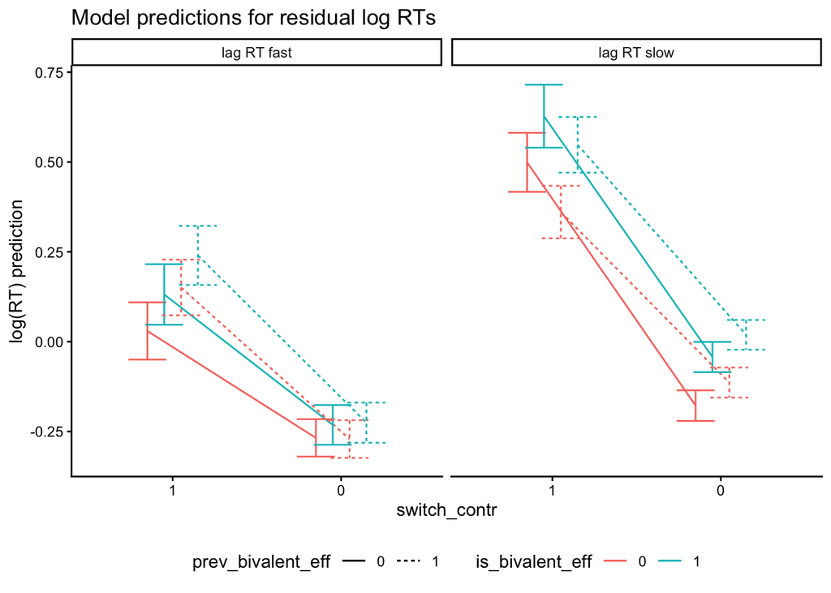

```r
ggplot(preds, aes(x = switch_contr, y = emmean, color = is_bivalent_eff, linetype = prev_bivalent_eff, group = interaction(is_bivalent_eff, prev_bivalent_eff)))+
  geom_line(position = pos)+
  geom_errorbar(aes(ymin = asymp.LCL, ymax = asymp.UCL), position = pos)+
  scale_x_discrete(limits = c("1", "0"))+
  facet_wrap(~speed, labeller = labeller(speed = c("slow" = "lag RT slow",
                                                   "fast" = "lag RT fast")))+
  labs(title = "Model predictions for residual log RTs",
       y = "log(RT) prediction")+
  theme_classic()+
  theme(legend.position = "bottom")
```

#### 7.1.1.1 Adding a lag switch

```r
alt_cue <- alt_cue %>%
  group_by(id, block) %>%
  mutate(lagSwitch_contr = lag(switch_contr, 1))

alt_cue_rt_log_resrt_eff_w_s_int_lagswitch_switch_is_bivalent <- xfun::cache_rds({
  lmer(time_log_res_w_s_int_c ~ is_bivalent_eff * prev_bivalent_eff * switch_contr * lag1_time_log_res_w_s_int_c + lagSwitch_contr +
         (lag1_time_log_res_w_s_int_c + switch_contr + is_bivalent_eff + lagSwitch_contr| id),
       control = lmerControl(optimizer = "bobyqa"),
       alt_cue %>% filter(filter_correct == 0)
  )
}, dir = "dominik/models/", file = "alt_cue_rt_log_resrt_eff_w_s_int_lagswitch_switch_is_bivalent.RDS", rerun = rerun_all)

summary(alt_cue_rt_log_resrt_eff_w_s_int_is_bivalent_switch)
```

```
## Linear mixed model fit by REML. t-tests use Satterthwaite's method [
## lmerModLmerTest]
## Formula: time_log_res_w_s_int_c ~ is_bivalent_eff * prev_bivalent_eff *
##     switch_contr * lag1_time_log_res_w_s_int_c + (lag1_time_log_res_w_s_int_c +
##     switch_contr + is_bivalent_eff | id)
##    Data: alt_cue %>% filter(filter_correct == 0)
## Control: lmerControl(optimizer = "bobyqa")
##
## REML criterion at convergence: 30453.3
##
## Scaled residuals:
##    Min     1Q Median     3Q    Max
## -5.080 -0.662 -0.091  0.518  5.565
##
## Random effects:
##  Groups   Name                        Variance Std.Dev. Corr
##  id       (Intercept)                 0.020514 0.14323
##           lag1_time_log_res_w_s_int_c 0.001737 0.04168  -0.49
##           switch_contr1               0.020492 0.14315   0.25 -0.35
##           is_bivalent_eff1            0.001769 0.04206   0.47 -0.26  0.08
##  Residual                             0.136338 0.36924
## Number of obs: 35199, groups:  id, 71
##
## Fixed effects:
##                                                                                 Estimate
## (Intercept)                                                                   -1.640e-01
## is_bivalent_eff1                                                               8.744e-02
## prev_bivalent_eff1                                                             3.221e-02
## switch_contr1                                                                  4.873e-01
## lag1_time_log_res_w_s_int_c                                                    5.670e-02
## is_bivalent_eff1:prev_bivalent_eff1                                            3.509e-03
## is_bivalent_eff1:switch_contr1                                                 3.913e-02
## prev_bivalent_eff1:switch_contr1                                              -2.923e-02
## is_bivalent_eff1:lag1_time_log_res_w_s_int_c                                   3.104e-02
## prev_bivalent_eff1:lag1_time_log_res_w_s_int_c                                 2.053e-02
## switch_contr1:lag1_time_log_res_w_s_int_c                                      6.689e-02
## is_bivalent_eff1:prev_bivalent_eff1:switch_contr1                              1.964e-02
## is_bivalent_eff1:prev_bivalent_eff1:lag1_time_log_res_w_s_int_c               -3.924e-03
## is_bivalent_eff1:switch_contr1:lag1_time_log_res_w_s_int_c                    -1.022e-02
## prev_bivalent_eff1:switch_contr1:lag1_time_log_res_w_s_int_c                  -9.514e-02
```

[output cut: 73 more lines]

```
## switch_contr1                                                                 ***
## lag1_time_log_res_w_s_int_c                                                   ***
## is_bivalent_eff1:prev_bivalent_eff1
## is_bivalent_eff1:switch_contr1                                                ***
## prev_bivalent_eff1:switch_contr1                                              **
## is_bivalent_eff1:lag1_time_log_res_w_s_int_c                                  **
## prev_bivalent_eff1:lag1_time_log_res_w_s_int_c                                *
## switch_contr1:lag1_time_log_res_w_s_int_c                                     ***
## is_bivalent_eff1:prev_bivalent_eff1:switch_contr1
## is_bivalent_eff1:prev_bivalent_eff1:lag1_time_log_res_w_s_int_c
## is_bivalent_eff1:switch_contr1:lag1_time_log_res_w_s_int_c
## prev_bivalent_eff1:switch_contr1:lag1_time_log_res_w_s_int_c                  ***
## is_bivalent_eff1:prev_bivalent_eff1:switch_contr1:lag1_time_log_res_w_s_int_c
## ---
## Signif. codes:  0 '***' 0.001 '**' 0.01 '*' 0.05 '.' 0.1 ' ' 1
```

```
##
## Correlation matrix not shown by default, as p = 16 > 12.
## Use print(x, correlation=TRUE)  or
##     vcov(x)        if you need it
```

```r
summary(alt_cue_rt_log_resrt_eff_w_s_int_lagswitch_switch_is_bivalent)
```

```
## Linear mixed model fit by REML. t-tests use Satterthwaite's method [
## lmerModLmerTest]
## Formula: time_log_res_w_s_int_c ~ is_bivalent_eff * prev_bivalent_eff *
##     switch_contr * lag1_time_log_res_w_s_int_c + lagSwitch_contr +
##     (lag1_time_log_res_w_s_int_c + switch_contr + is_bivalent_eff +
##         lagSwitch_contr | id)
##    Data: alt_cue %>% filter(filter_correct == 0)
## Control: lmerControl(optimizer = "bobyqa")
##
## REML criterion at convergence: 30401.9
##
## Scaled residuals:
##     Min      1Q  Median      3Q     Max
## -5.0726 -0.6620 -0.0900  0.5194  5.5337
##
## Random effects:
##  Groups   Name                        Variance Std.Dev. Corr
##  id       (Intercept)                 0.020317 0.14254
##           lag1_time_log_res_w_s_int_c 0.001695 0.04118  -0.59
##           switch_contr1               0.020940 0.14471   0.24 -0.42
##           is_bivalent_eff1            0.001731 0.04160   0.54 -0.05  0.02
##           lagSwitch_contr1            0.001662 0.04076   0.15 -0.12  0.27 -0.46
##  Residual                             0.135979 0.36875
## Number of obs: 35199, groups:  id, 71
##
## Fixed effects:
##                                                                                 Estimate
## (Intercept)                                                                   -1.765e-01
## is_bivalent_eff1                                                               8.901e-02
## prev_bivalent_eff1                                                             3.301e-02
## switch_contr1                                                                  5.002e-01
## lag1_time_log_res_w_s_int_c                                                    4.111e-02
## lagSwitch_contr1                                                               2.946e-02
## is_bivalent_eff1:prev_bivalent_eff1                                            3.282e-03
## is_bivalent_eff1:switch_contr1                                                 3.753e-02
## prev_bivalent_eff1:switch_contr1                                              -3.039e-02
## is_bivalent_eff1:lag1_time_log_res_w_s_int_c                                   3.567e-02
## prev_bivalent_eff1:lag1_time_log_res_w_s_int_c                                 2.173e-02
## switch_contr1:lag1_time_log_res_w_s_int_c                                      8.223e-02
## is_bivalent_eff1:prev_bivalent_eff1:switch_contr1                              2.000e-02
```

[output cut: 81 more lines]

```
## lag1_time_log_res_w_s_int_c                                                   ***
## lagSwitch_contr1                                                              ***
## is_bivalent_eff1:prev_bivalent_eff1
## is_bivalent_eff1:switch_contr1                                                ***
## prev_bivalent_eff1:switch_contr1                                              ***
## is_bivalent_eff1:lag1_time_log_res_w_s_int_c                                  ***
## prev_bivalent_eff1:lag1_time_log_res_w_s_int_c                                *
## switch_contr1:lag1_time_log_res_w_s_int_c                                     ***
## is_bivalent_eff1:prev_bivalent_eff1:switch_contr1
## is_bivalent_eff1:prev_bivalent_eff1:lag1_time_log_res_w_s_int_c
## is_bivalent_eff1:switch_contr1:lag1_time_log_res_w_s_int_c
## prev_bivalent_eff1:switch_contr1:lag1_time_log_res_w_s_int_c                  ***
## is_bivalent_eff1:prev_bivalent_eff1:switch_contr1:lag1_time_log_res_w_s_int_c
## ---
## Signif. codes:  0 '***' 0.001 '**' 0.01 '*' 0.05 '.' 0.1 ' ' 1
```

```
##
## Correlation matrix not shown by default, as p = 17 > 12.
## Use print(x, correlation=TRUE)  or
##     vcov(x)        if you need it
```

```r
anova(alt_cue_rt_log_resrt_eff_w_s_int_lagswitch_switch_is_bivalent, alt_cue_rt_log_resrt_eff_w_s_int_is_bivalent_switch)
```

```
## refitting model(s) with ML (instead of REML)
```

```
## Data: alt_cue %>% filter(filter_correct == 0)
## Models:
## alt_cue_rt_log_resrt_eff_w_s_int_is_bivalent_switch: time_log_res_w_s_int_c ~ is_bivalent_eff * prev_bivalent_eff * switch_contr * lag1_time_log_res_w_s_int_c + (lag1_time_log_res_w_s_int_c + switch_contr + is_bivalent_eff | id)
## alt_cue_rt_log_resrt_eff_w_s_int_lagswitch_switch_is_bivalent: time_log_res_w_s_int_c ~ is_bivalent_eff * prev_bivalent_eff * switch_contr * lag1_time_log_res_w_s_int_c + lagSwitch_contr + (lag1_time_log_res_w_s_int_c + switch_contr + is_bivalent_eff + lagSwitch_contr | id)
##                                                               npar   AIC   BIC
## alt_cue_rt_log_resrt_eff_w_s_int_is_bivalent_switch             27 30394 30623
## alt_cue_rt_log_resrt_eff_w_s_int_lagswitch_switch_is_bivalent   33 30347 30626
##                                                               logLik -2*log(L)
## alt_cue_rt_log_resrt_eff_w_s_int_is_bivalent_switch           -15170     30340
## alt_cue_rt_log_resrt_eff_w_s_int_lagswitch_switch_is_bivalent -15140     30281
##                                                                Chisq Df
## alt_cue_rt_log_resrt_eff_w_s_int_is_bivalent_switch
## alt_cue_rt_log_resrt_eff_w_s_int_lagswitch_switch_is_bivalent 59.602  6
##                                                               Pr(>Chisq)
## alt_cue_rt_log_resrt_eff_w_s_int_is_bivalent_switch
## alt_cue_rt_log_resrt_eff_w_s_int_lagswitch_switch_is_bivalent  5.422e-11 ***
## ---
## Signif. codes:  0 '***' 0.001 '**' 0.01 '*' 0.05 '.' 0.1 ' ' 1
```

#### 7.1.1.2 Coding position 2 as NA

One issue with the previous analysis is that the lag RT for the first trial after the switch is a switch RT. Therefore, I am here coding that RT as NA.

```r
alt_cue_withinID_cycle2NA <- alt_cue %>%
  filter(filter_correct == 0) %>%
  mutate(lag1_time_log_res_w_s_int_c = ifelse(cycle == 2, NA, lag1_time_log_res_w_s_int_c))

alt_cue_rt_log_resrt_eff_w_s_int_cy2NA_is_bivalent_switch <- xfun::cache_rds({
  lmer(time_log_res_w_s_int_c ~ is_bivalent_eff * prev_bivalent_eff * switch_contr * lag1_time_log_res_w_s_int_c +
         (lag1_time_log_res_w_s_int_c + switch_contr + is_bivalent_eff| id),
       control = lmerControl(optimizer = "bobyqa"),
       alt_cue_withinID_cycle2NA
  )
}, dir = "dominik/models/", file = "alt_cue_rt_log_resrt_eff_w_s_int_cy2NA_is_bivalent_switch.RDS", rerun = rerun_all)

summary(alt_cue_rt_log_resrt_eff_w_s_int_cy2NA_is_bivalent_switch)
```

```
## Linear mixed model fit by REML. t-tests use Satterthwaite's method [
## lmerModLmerTest]
## Formula: time_log_res_w_s_int_c ~ is_bivalent_eff * prev_bivalent_eff *
##     switch_contr * lag1_time_log_res_w_s_int_c + (lag1_time_log_res_w_s_int_c +
##     switch_contr + is_bivalent_eff | id)
##    Data: alt_cue_withinID_cycle2NA
## Control: lmerControl(optimizer = "bobyqa")
##
## REML criterion at convergence: 20518
##
## Scaled residuals:
##     Min      1Q  Median      3Q     Max
## -5.0707 -0.6691 -0.0911  0.5335  5.5081
##
## Random effects:
##  Groups   Name                        Variance Std.Dev. Corr
##  id       (Intercept)                 0.019183 0.13850
##           lag1_time_log_res_w_s_int_c 0.002005 0.04478  -0.51
##           switch_contr1               0.021399 0.14628   0.25 -0.44
##           is_bivalent_eff1            0.001858 0.04311   0.44 -0.12 -0.06
##  Residual                             0.136434 0.36937
## Number of obs: 23518, groups:  id, 71
##
## Fixed effects:
##                                                                                 Estimate
## (Intercept)                                                                   -1.697e-01
## is_bivalent_eff1                                                               7.326e-02
## prev_bivalent_eff1                                                             7.135e-03
## switch_contr1                                                                  4.936e-01
## lag1_time_log_res_w_s_int_c                                                    7.691e-02
## is_bivalent_eff1:prev_bivalent_eff1                                            9.363e-03
## is_bivalent_eff1:switch_contr1                                                 5.415e-02
## prev_bivalent_eff1:switch_contr1                                              -4.328e-03
## is_bivalent_eff1:lag1_time_log_res_w_s_int_c                                  -6.856e-03
## prev_bivalent_eff1:lag1_time_log_res_w_s_int_c                                -2.147e-02
## switch_contr1:lag1_time_log_res_w_s_int_c                                      4.744e-02
## is_bivalent_eff1:prev_bivalent_eff1:switch_contr1                              1.347e-02
## is_bivalent_eff1:prev_bivalent_eff1:lag1_time_log_res_w_s_int_c                1.417e-02
## is_bivalent_eff1:switch_contr1:lag1_time_log_res_w_s_int_c                     3.158e-02
## prev_bivalent_eff1:switch_contr1:lag1_time_log_res_w_s_int_c                  -5.314e-02
```

[output cut: 73 more lines]

```
## switch_contr1                                                                 ***
## lag1_time_log_res_w_s_int_c                                                   ***
## is_bivalent_eff1:prev_bivalent_eff1
## is_bivalent_eff1:switch_contr1                                                ***
## prev_bivalent_eff1:switch_contr1
## is_bivalent_eff1:lag1_time_log_res_w_s_int_c
## prev_bivalent_eff1:lag1_time_log_res_w_s_int_c
## switch_contr1:lag1_time_log_res_w_s_int_c                                     ***
## is_bivalent_eff1:prev_bivalent_eff1:switch_contr1
## is_bivalent_eff1:prev_bivalent_eff1:lag1_time_log_res_w_s_int_c
## is_bivalent_eff1:switch_contr1:lag1_time_log_res_w_s_int_c
## prev_bivalent_eff1:switch_contr1:lag1_time_log_res_w_s_int_c                  *
## is_bivalent_eff1:prev_bivalent_eff1:switch_contr1:lag1_time_log_res_w_s_int_c
## ---
## Signif. codes:  0 '***' 0.001 '**' 0.01 '*' 0.05 '.' 0.1 ' ' 1
```

```
##
## Correlation matrix not shown by default, as p = 16 > 12.
## Use print(x, correlation=TRUE)  or
##     vcov(x)        if you need it
```

```r
model_comp(summary(alt_cue_rt_log_resrt_eff_w_s_int_cy2NA_is_bivalent_switch), summary(alt_cue_rt_log_resrt_eff_w_s_int_is_bivalent_switch))
```

| Rows with differences in signs of estimates or binary significance (shared terms only) are bolded. term | Rows with differences in signs of estimates or binary significance (shared terms only) are bolded. Estimate_m1 | Rows with differences in signs of estimates or binary significance (shared terms only) are bolded. Estimate_m2 | Rows with differences in signs of estimates or binary significance (shared terms only) are bolded. p_m1 | Rows with differences in signs of estimates or binary significance (shared terms only) are bolded. p_m2 |
| --- | --- | --- | --- | --- |
| (Intercept) | -0.170 | -0.164 | 0.0000 | 0.0000 |
| is_bivalent_eff1 | 0.073 | 0.087 | 0.0000 | 0.0000 |
| prev_bivalent_eff1 | 0.007 | 0.032 | 0.3210 | 0.0000 |
| switch_contr1 | 0.494 | 0.487 | 0.0000 | 0.0000 |
| lag1_time_log_res_w_s_int_c | 0.077 | 0.057 | 0.0000 | 0.0000 |
| is_bivalent_eff1:prev_bivalent_eff1 | 0.009 | 0.004 | 0.5140 | 0.7220 |
| is_bivalent_eff1:switch_contr1 | 0.054 | 0.039 | 0.0000 | 0.0000 |
| prev_bivalent_eff1:switch_contr1 | -0.004 | -0.029 | 0.6820 | 0.0010 |
| is_bivalent_eff1:lag1_time_log_res_w_s_int_c | -0.007 | 0.031 | 0.6860 | 0.0020 |
| prev_bivalent_eff1:lag1_time_log_res_w_s_int_c | -0.021 | 0.021 | 0.1980 | 0.0370 |
| switch_contr1:lag1_time_log_res_w_s_int_c | 0.047 | 0.067 | 0.0000 | 0.0000 |
| is_bivalent_eff1:prev_bivalent_eff1:switch_contr1 | 0.013 | 0.020 | 0.5230 | 0.2840 |
| is_bivalent_eff1:prev_bivalent_eff1:lag1_time_log_res_w_s_int_c | 0.014 | -0.004 | 0.6710 | 0.8420 |
| is_bivalent_eff1:switch_contr1:lag1_time_log_res_w_s_int_c | 0.032 | -0.010 | 0.2100 | 0.6310 |
| prev_bivalent_eff1:switch_contr1:lag1_time_log_res_w_s_int_c | -0.053 | -0.095 | 0.0350 | 0.0000 |
| is_bivalent_eff1:prev_bivalent_eff1:switch_contr1:lag1_time_log_res_w_s_int_c | 0.009 | 0.028 | 0.8570 | 0.5160 |

```r
preds <- emmeans::emmeans(alt_cue_rt_log_resrt_eff_w_s_int_cy2NA_is_bivalent_switch, ~ is_bivalent_eff * prev_bivalent_eff * switch_contr * lag1_time_log_res_w_s_int_c, type = "response",
                          at = list(is_bivalent_eff = factor(c(0, 1)),
                                    prev_bivalent_eff = factor(c(0, 1)),
                                    switch_contr = factor(c(0, 1)),
                                    lag1_time_log_res_w_s_int_c = c(-1.5, 1.5))) %>%
  as.data.frame() %>%
  mutate(speed = case_when(lag1_time_log_res_w_s_int_c == min(lag1_time_log_res_w_s_int_c) ~ "fast",
                           lag1_time_log_res_w_s_int_c == max(lag1_time_log_res_w_s_int_c) ~ "slow") %>% factor())
```

```
## Note: D.f. calculations have been disabled because the number of observations exceeds 3000.
## To enable adjustments, add the argument 'pbkrtest.limit = 23518' (or larger)
## [or, globally, 'set emm_options(pbkrtest.limit = 23518)' or larger];
## but be warned that this may result in large computation time and memory use.
```

```
## Note: D.f. calculations have been disabled because the number of observations exceeds 3000.
## To enable adjustments, add the argument 'lmerTest.limit = 23518' (or larger)
## [or, globally, 'set emm_options(lmerTest.limit = 23518)' or larger];
## but be warned that this may result in large computation time and memory use.
```

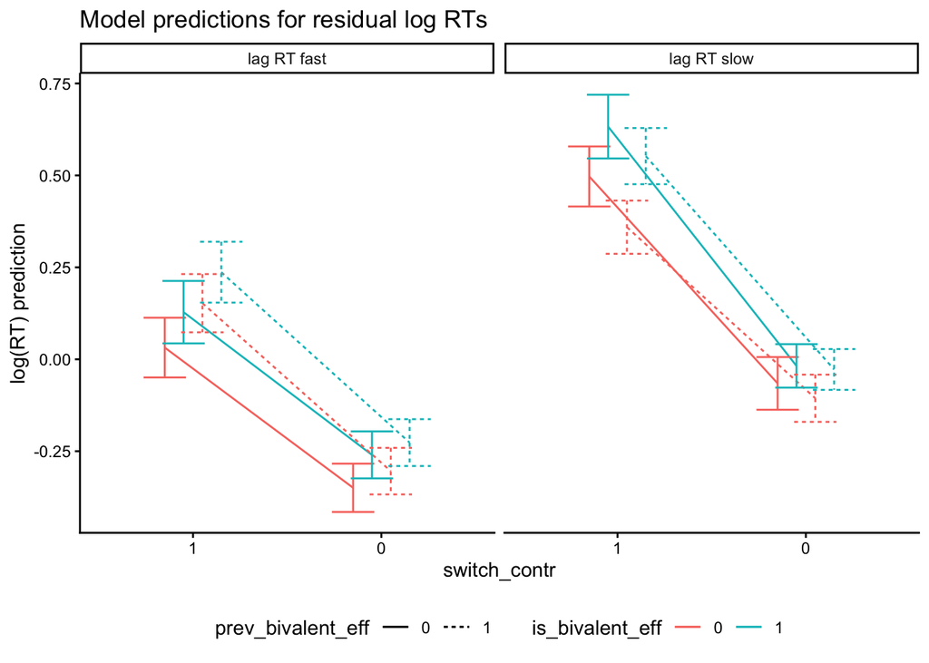

```r
ggplot(preds, aes(x = switch_contr, y = emmean, color = is_bivalent_eff, linetype = prev_bivalent_eff, group = interaction(is_bivalent_eff, prev_bivalent_eff)))+
  geom_line(position = pos)+
  geom_errorbar(aes(ymin = asymp.LCL, ymax = asymp.UCL), position = pos)+
  scale_x_discrete(limits = c("1", "0"))+
  facet_wrap(~speed, labeller = labeller(speed = c("slow" = "lag RT slow",
                                                   "fast" = "lag RT fast")))+
  labs(title = "Model predictions for residual log RTs",
       y = "log(RT) prediction")+
  theme_classic()+
  theme(legend.position = "bottom")
```

#### 7.1.1.3 Using the mean NS RT from previous group

```r
alt_cue <- alt_cue %>%
  group_by(id, block, trialgroup) %>%
  mutate(Avg_NS_RT_log_res_w_s_int_c = mean(lag1_time_log_res_w_s_int_c[switch == 0], na.rm = TRUE)) %>%
  group_by(id, block) %>%
  mutate(prev_group_Avg_NS_RT_log_res_w_s_int_c = lag(Avg_NS_RT_log_res_w_s_int_c, 1)) %>%
  group_by(id, block, trialgroup) %>%
  mutate(prev_group_Avg_NS_RT_log_res_w_s_int_c = prev_group_Avg_NS_RT_log_res_w_s_int_c[1])



alt_cue_rt_log_resrt_eff_w_s_int_rt_prevgroup_is_bivalent_switch <- xfun::cache_rds({
  lmer(time_log_res_w_s_int_c ~ is_bivalent_eff * prev_bivalent_eff * switch_contr * prev_group_Avg_NS_RT_log_res_w_s_int_c +
         (prev_group_Avg_NS_RT_log_res_w_s_int_c + switch_contr + is_bivalent_eff| id),
       control = lmerControl(optimizer = "bobyqa"),
       alt_cue %>%
         filter(filter_correct == 0)
  )
}, dir = "dominik/models/", file = "alt_cue_rt_log_resrt_eff_w_s_int_rt_prevgroup_is_bivalent_switch.RDS", rerun = rerun_all)

summary(alt_cue_rt_log_resrt_eff_w_s_int_rt_prevgroup_is_bivalent_switch)
```

```
## Linear mixed model fit by REML. t-tests use Satterthwaite's method [
## lmerModLmerTest]
## Formula: time_log_res_w_s_int_c ~ is_bivalent_eff * prev_bivalent_eff *
##     switch_contr * prev_group_Avg_NS_RT_log_res_w_s_int_c + (prev_group_Avg_NS_RT_log_res_w_s_int_c +
##     switch_contr + is_bivalent_eff | id)
##    Data: alt_cue %>% filter(filter_correct == 0)
## Control: lmerControl(optimizer = "bobyqa")
##
## REML criterion at convergence: 29737.4
##
## Scaled residuals:
##     Min      1Q  Median      3Q     Max
## -4.9525 -0.6635 -0.0940  0.5157  5.6273
##
## Random effects:
##  Groups   Name                                   Variance  Std.Dev. Corr
##  id       (Intercept)                            0.0241040 0.15525
##           prev_group_Avg_NS_RT_log_res_w_s_int_c 0.0005945 0.02438  -0.92
##           switch_contr1                          0.0189867 0.13779   0.32 -0.34
##           is_bivalent_eff1                       0.0020375 0.04514   0.46 -0.15
##  Residual                                        0.1374271 0.37071
##
##
##
##
##   0.12
##
## Number of obs: 34080, groups:  id, 71
##
## Fixed effects:
##                                                                                            Estimate
## (Intercept)                                                                              -1.575e-01
## is_bivalent_eff1                                                                          9.525e-02
## prev_bivalent_eff1                                                                        3.632e-02
## switch_contr1                                                                             4.520e-01
## prev_group_Avg_NS_RT_log_res_w_s_int_c                                                   -5.750e-03
## is_bivalent_eff1:prev_bivalent_eff1                                                       6.758e-03
## is_bivalent_eff1:switch_contr1                                                            2.610e-02
## prev_bivalent_eff1:switch_contr1                                                         -1.632e-02
## is_bivalent_eff1:prev_group_Avg_NS_RT_log_res_w_s_int_c                                   1.028e-02
```

[output cut: 79 more lines]

```
## switch_contr1                                                                            ***
## prev_group_Avg_NS_RT_log_res_w_s_int_c
## is_bivalent_eff1:prev_bivalent_eff1
## is_bivalent_eff1:switch_contr1                                                           **
## prev_bivalent_eff1:switch_contr1                                                         .
## is_bivalent_eff1:prev_group_Avg_NS_RT_log_res_w_s_int_c
## prev_bivalent_eff1:prev_group_Avg_NS_RT_log_res_w_s_int_c
## switch_contr1:prev_group_Avg_NS_RT_log_res_w_s_int_c                                     ***
## is_bivalent_eff1:prev_bivalent_eff1:switch_contr1
## is_bivalent_eff1:prev_bivalent_eff1:prev_group_Avg_NS_RT_log_res_w_s_int_c
## is_bivalent_eff1:switch_contr1:prev_group_Avg_NS_RT_log_res_w_s_int_c
## prev_bivalent_eff1:switch_contr1:prev_group_Avg_NS_RT_log_res_w_s_int_c
## is_bivalent_eff1:prev_bivalent_eff1:switch_contr1:prev_group_Avg_NS_RT_log_res_w_s_int_c
## ---
## Signif. codes:  0 '***' 0.001 '**' 0.01 '*' 0.05 '.' 0.1 ' ' 1
```

```
##
## Correlation matrix not shown by default, as p = 16 > 12.
## Use print(x, correlation=TRUE)  or
##     vcov(x)        if you need it
```

```r
model_comp(
  summary(alt_cue_rt_log_resrt_eff_w_s_int_rt_prevgroup_is_bivalent_switch), summary(alt_cue_rt_log_resrt_eff_w_s_int_is_bivalent_switch))
```

| Rows with differences in signs of estimates or binary significance (shared terms only) are bolded. term | Rows with differences in signs of estimates or binary significance (shared terms only) are bolded. Estimate_m1 | Rows with differences in signs of estimates or binary significance (shared terms only) are bolded. Estimate_m2 | Rows with differences in signs of estimates or binary significance (shared terms only) are bolded. p_m1 | Rows with differences in signs of estimates or binary significance (shared terms only) are bolded. p_m2 |
| --- | --- | --- | --- | --- |
| (Intercept) | -0.158 | -0.164 | 0.0000 | 0.0000 |
| is_bivalent_eff1 | 0.095 | 0.087 | 0.0000 | 0.0000 |
| prev_bivalent_eff1 | 0.036 | 0.032 | 0.0000 | 0.0000 |
| switch_contr1 | 0.452 | 0.487 | 0.0000 | 0.0000 |
| prev_group_Avg_NS_RT_log_res_w_s_int_c | -0.006 |  | 0.4900 |  |
| is_bivalent_eff1:prev_bivalent_eff1 | 0.007 | 0.004 | 0.5130 | 0.7220 |
| is_bivalent_eff1:switch_contr1 | 0.026 | 0.039 | 0.0040 | 0.0000 |
| prev_bivalent_eff1:switch_contr1 | -0.016 | -0.029 | 0.0690 | 0.0010 |
| is_bivalent_eff1:prev_group_Avg_NS_RT_log_res_w_s_int_c | 0.010 |  | 0.4740 |  |
| prev_bivalent_eff1:prev_group_Avg_NS_RT_log_res_w_s_int_c | 0.018 |  | 0.1900 |  |
| switch_contr1:prev_group_Avg_NS_RT_log_res_w_s_int_c | 0.060 |  | 0.0000 |  |
| is_bivalent_eff1:prev_bivalent_eff1:switch_contr1 | 0.015 | 0.020 | 0.4140 | 0.2840 |
| is_bivalent_eff1:prev_bivalent_eff1:prev_group_Avg_NS_RT_log_res_w_s_int_c | -0.000 |  | 0.9870 |  |
| is_bivalent_eff1:switch_contr1:prev_group_Avg_NS_RT_log_res_w_s_int_c | 0.002 |  | 0.9240 |  |
| prev_bivalent_eff1:switch_contr1:prev_group_Avg_NS_RT_log_res_w_s_int_c | -0.022 |  | 0.3610 |  |
| is_bivalent_eff1:prev_bivalent_eff1:switch_contr1:prev_group_Avg_NS_RT_log_res_w_s_int_c | 0.003 |  | 0.9570 |  |
| lag1_time_log_res_w_s_int_c |  | 0.057 |  | 0.0000 |
| is_bivalent_eff1:lag1_time_log_res_w_s_int_c |  | 0.031 |  | 0.0020 |
| prev_bivalent_eff1:lag1_time_log_res_w_s_int_c |  | 0.021 |  | 0.0370 |
| switch_contr1:lag1_time_log_res_w_s_int_c |  | 0.067 |  | 0.0000 |
| is_bivalent_eff1:prev_bivalent_eff1:lag1_time_log_res_w_s_int_c |  | -0.004 |  | 0.8420 |
| is_bivalent_eff1:switch_contr1:lag1_time_log_res_w_s_int_c |  | -0.010 |  | 0.6310 |
| prev_bivalent_eff1:switch_contr1:lag1_time_log_res_w_s_int_c |  | -0.095 |  | 0.0000 |
| is_bivalent_eff1:prev_bivalent_eff1:switch_contr1:lag1_time_log_res_w_s_int_c |  | 0.028 |  | 0.5160 |

```r
preds <- emmeans::emmeans(alt_cue_rt_log_resrt_eff_w_s_int_rt_prevgroup_is_bivalent_switch, ~ is_bivalent_eff * prev_bivalent_eff * switch_contr * prev_group_Avg_NS_RT_log_res_w_s_int_c, type = "response",
                          at = list(is_bivalent_eff = factor(c(0, 1)),
                                    prev_bivalent_eff = factor(c(0, 1)),
                                    switch_contr = factor(c(0, 1)),
                                    prev_group_Avg_NS_RT_log_res_w_s_int_c = c(-1.5, 1.5))) %>%
  as.data.frame() %>%
  mutate(speed = case_when(prev_group_Avg_NS_RT_log_res_w_s_int_c == min(prev_group_Avg_NS_RT_log_res_w_s_int_c) ~ "fast",
                           prev_group_Avg_NS_RT_log_res_w_s_int_c == max(prev_group_Avg_NS_RT_log_res_w_s_int_c) ~ "slow") %>% factor())
```

```
## Note: D.f. calculations have been disabled because the number of observations exceeds 3000.
## To enable adjustments, add the argument 'pbkrtest.limit = 34080' (or larger)
## [or, globally, 'set emm_options(pbkrtest.limit = 34080)' or larger];
## but be warned that this may result in large computation time and memory use.
```

```
## Note: D.f. calculations have been disabled because the number of observations exceeds 3000.
## To enable adjustments, add the argument 'lmerTest.limit = 34080' (or larger)
## [or, globally, 'set emm_options(lmerTest.limit = 34080)' or larger];
## but be warned that this may result in large computation time and memory use.
```

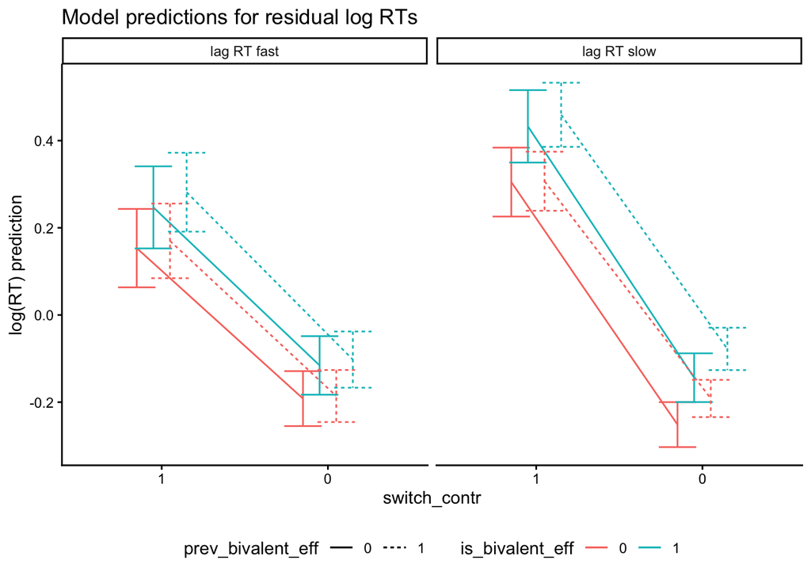

```r
ggplot(preds, aes(x = switch_contr, y = emmean, color = is_bivalent_eff, linetype = prev_bivalent_eff, group = interaction(is_bivalent_eff, prev_bivalent_eff)))+
  geom_line(position = pos)+
  geom_errorbar(aes(ymin = asymp.LCL, ymax = asymp.UCL), position = pos)+
  scale_x_discrete(limits = c("1", "0"))+
  facet_wrap(~speed, labeller = labeller(speed = c("slow" = "lag RT slow",
                                                   "fast" = "lag RT fast")))+
  labs(title = "Model predictions for residual log RTs",
       y = "log(RT) prediction")+
  theme_classic()+
  theme(legend.position = "bottom")
```

```r
make_model_table(alt_cue_rt_log_resrt_eff_w_s_int_is_bivalent_switch)
```

| Call: lmer(formula = time_log_res_w_s_int_c ~ is_bivalent_eff * prev_bivalent_eff * switch_contr * lag1_time_log_res_w_s_int_c + (lag1_time_log_res_w_s_int_c + switch_contr + is_bivalent_eff \| id), d… term | Call: lmer(formula = time_log_res_w_s_int_c ~ is_bivalent_eff * prev_bivalent_eff * switch_contr * lag1_time_log_res_w_s_int_c + (lag1_time_log_res_w_s_int_c + switch_contr + is_bivalent_eff \| id), d… Estimate | Call: lmer(formula = time_log_res_w_s_int_c ~ is_bivalent_eff * prev_bivalent_eff * switch_contr * lag1_time_log_res_w_s_int_c + (lag1_time_log_res_w_s_int_c + switch_contr + is_bivalent_eff \| id), d… Std. Error | Call: lmer(formula = time_log_res_w_s_int_c ~ is_bivalent_eff * prev_bivalent_eff * switch_contr * lag1_time_log_res_w_s_int_c + (lag1_time_log_res_w_s_int_c + switch_contr + is_bivalent_eff \| id), d… df | Call: lmer(formula = time_log_res_w_s_int_c ~ is_bivalent_eff * prev_bivalent_eff * switch_contr * lag1_time_log_res_w_s_int_c + (lag1_time_log_res_w_s_int_c + switch_contr + is_bivalent_eff \| id), d… t value | Call: lmer(formula = time_log_res_w_s_int_c ~ is_bivalent_eff * prev_bivalent_eff * switch_contr * lag1_time_log_res_w_s_int_c + (lag1_time_log_res_w_s_int_c + switch_contr + is_bivalent_eff \| id), d… Pr(>\|t\|) |
| --- | --- | --- | --- | --- | --- |
| (Intercept) | -0.16 | 0.02 | 69.34 | -9.54 | 0.0000 |
| is_bivalent_eff1 | 0.09 | 0.01 | 101.12 | 12.45 | 0.0000 |
| prev_bivalent_eff1 | 0.03 | 0.00 | 35,047.29 | 6.53 | 0.0000 |
| switch_contr1 | 0.49 | 0.02 | 71.05 | 27.66 | 0.0000 |
| lag1_time_log_res_w_s_int_c | 0.06 | 0.01 | 86.47 | 7.71 | 0.0000 |
| is_bivalent_eff1:prev_bivalent_eff1 | 0.00 | 0.01 | 35,047.68 | 0.36 | 0.7222 |
| is_bivalent_eff1:switch_contr1 | 0.04 | 0.01 | 34,650.68 | 4.25 | 0.0000 |
| prev_bivalent_eff1:switch_contr1 | -0.03 | 0.01 | 35,023.18 | -3.18 | 0.0015 |
| is_bivalent_eff1:lag1_time_log_res_w_s_int_c | 0.03 | 0.01 | 16,054.65 | 3.06 | 0.0022 |
| prev_bivalent_eff1:lag1_time_log_res_w_s_int_c | 0.02 | 0.01 | 34,780.88 | 2.09 | 0.0370 |
| switch_contr1:lag1_time_log_res_w_s_int_c | 0.07 | 0.01 | 32,605.47 | 5.81 | 0.0000 |
| is_bivalent_eff1:prev_bivalent_eff1:switch_contr1 | 0.02 | 0.02 | 35,023.68 | 1.07 | 0.2839 |
| is_bivalent_eff1:prev_bivalent_eff1:lag1_time_log_res_w_s_int_c | -0.00 | 0.02 | 34,831.97 | -0.20 | 0.8419 |
| is_bivalent_eff1:switch_contr1:lag1_time_log_res_w_s_int_c | -0.01 | 0.02 | 34,797.02 | -0.48 | 0.6313 |
| prev_bivalent_eff1:switch_contr1:lag1_time_log_res_w_s_int_c | -0.10 | 0.02 | 35,006.09 | -4.47 | 0.0000 |
| is_bivalent_eff1:prev_bivalent_eff1:switch_contr1:lag1_time_log_res_w_s_int_c | 0.03 | 0.04 | 35,045.27 | 0.65 | 0.5156 |

```r
make_model_table(alt_cue_rt_log_resrt_eff_w_s_int_cy2NA_is_bivalent_switch)
```

| Call: lmer(formula = time_log_res_w_s_int_c ~ is_bivalent_eff * prev_bivalent_eff * switch_contr * lag1_time_log_res_w_s_int_c + (lag1_time_log_res_w_s_int_c + switch_contr + is_bivalent_eff \| id), d… term | Call: lmer(formula = time_log_res_w_s_int_c ~ is_bivalent_eff * prev_bivalent_eff * switch_contr * lag1_time_log_res_w_s_int_c + (lag1_time_log_res_w_s_int_c + switch_contr + is_bivalent_eff \| id), d… Estimate | Call: lmer(formula = time_log_res_w_s_int_c ~ is_bivalent_eff * prev_bivalent_eff * switch_contr * lag1_time_log_res_w_s_int_c + (lag1_time_log_res_w_s_int_c + switch_contr + is_bivalent_eff \| id), d… Std. Error | Call: lmer(formula = time_log_res_w_s_int_c ~ is_bivalent_eff * prev_bivalent_eff * switch_contr * lag1_time_log_res_w_s_int_c + (lag1_time_log_res_w_s_int_c + switch_contr + is_bivalent_eff \| id), d… df | Call: lmer(formula = time_log_res_w_s_int_c ~ is_bivalent_eff * prev_bivalent_eff * switch_contr * lag1_time_log_res_w_s_int_c + (lag1_time_log_res_w_s_int_c + switch_contr + is_bivalent_eff \| id), d… t value | Call: lmer(formula = time_log_res_w_s_int_c ~ is_bivalent_eff * prev_bivalent_eff * switch_contr * lag1_time_log_res_w_s_int_c + (lag1_time_log_res_w_s_int_c + switch_contr + is_bivalent_eff \| id), d… Pr(>\|t\|) |
| --- | --- | --- | --- | --- | --- |
| (Intercept) | -0.17 | 0.02 | 69.55 | -10.08 | 0.0000 |
| is_bivalent_eff1 | 0.07 | 0.01 | 168.47 | 8.29 | 0.0000 |
| prev_bivalent_eff1 | 0.01 | 0.01 | 23,340.98 | 0.99 | 0.3205 |
| switch_contr1 | 0.49 | 0.02 | 72.17 | 27.16 | 0.0000 |
| lag1_time_log_res_w_s_int_c | 0.08 | 0.01 | 157.13 | 7.34 | 0.0000 |
| is_bivalent_eff1:prev_bivalent_eff1 | 0.01 | 0.01 | 23,351.52 | 0.65 | 0.5144 |
| is_bivalent_eff1:switch_contr1 | 0.05 | 0.01 | 23,352.70 | 5.13 | 0.0000 |
| prev_bivalent_eff1:switch_contr1 | -0.00 | 0.01 | 23,325.28 | -0.41 | 0.6820 |
| is_bivalent_eff1:lag1_time_log_res_w_s_int_c | -0.01 | 0.02 | 14,930.84 | -0.40 | 0.6863 |
| prev_bivalent_eff1:lag1_time_log_res_w_s_int_c | -0.02 | 0.02 | 23,042.44 | -1.29 | 0.1979 |
| switch_contr1:lag1_time_log_res_w_s_int_c | 0.05 | 0.01 | 21,090.95 | 3.51 | 0.0005 |
| is_bivalent_eff1:prev_bivalent_eff1:switch_contr1 | 0.01 | 0.02 | 23,350.44 | 0.64 | 0.5228 |
| is_bivalent_eff1:prev_bivalent_eff1:lag1_time_log_res_w_s_int_c | 0.01 | 0.03 | 22,749.86 | 0.43 | 0.6708 |
| is_bivalent_eff1:switch_contr1:lag1_time_log_res_w_s_int_c | 0.03 | 0.03 | 23,128.87 | 1.25 | 0.2100 |
| prev_bivalent_eff1:switch_contr1:lag1_time_log_res_w_s_int_c | -0.05 | 0.03 | 23,191.70 | -2.11 | 0.0350 |
| is_bivalent_eff1:prev_bivalent_eff1:switch_contr1:lag1_time_log_res_w_s_int_c | 0.01 | 0.05 | 23,245.62 | 0.18 | 0.8574 |

```r
make_model_table(alt_cue_rt_log_resrt_eff_w_s_int_rt_prevgroup_is_bivalent_switch)
```

| Call: lmer(formula = time_log_res_w_s_int_c ~ is_bivalent_eff * prev_bivalent_eff * switch_contr * prev_group_Avg_NS_RT_log_res_w_s_int_c + (prev_group_Avg_NS_RT_log_res_w_s_int_c + switch_contr + is_… term | Call: lmer(formula = time_log_res_w_s_int_c ~ is_bivalent_eff * prev_bivalent_eff * switch_contr * prev_group_Avg_NS_RT_log_res_w_s_int_c + (prev_group_Avg_NS_RT_log_res_w_s_int_c + switch_contr + is_… Estimate | Call: lmer(formula = time_log_res_w_s_int_c ~ is_bivalent_eff * prev_bivalent_eff * switch_contr * prev_group_Avg_NS_RT_log_res_w_s_int_c + (prev_group_Avg_NS_RT_log_res_w_s_int_c + switch_contr + is_… Std. Error | Call: lmer(formula = time_log_res_w_s_int_c ~ is_bivalent_eff * prev_bivalent_eff * switch_contr * prev_group_Avg_NS_RT_log_res_w_s_int_c + (prev_group_Avg_NS_RT_log_res_w_s_int_c + switch_contr + is_… df | Call: lmer(formula = time_log_res_w_s_int_c ~ is_bivalent_eff * prev_bivalent_eff * switch_contr * prev_group_Avg_NS_RT_log_res_w_s_int_c + (prev_group_Avg_NS_RT_log_res_w_s_int_c + switch_contr + is_… t value | Call: lmer(formula = time_log_res_w_s_int_c ~ is_bivalent_eff * prev_bivalent_eff * switch_contr * prev_group_Avg_NS_RT_log_res_w_s_int_c + (prev_group_Avg_NS_RT_log_res_w_s_int_c + switch_contr + is_… Pr(>\|t\|) |
| --- | --- | --- | --- | --- | --- |
| (Intercept) | -0.16 | 0.02 | 69.03 | -8.47 | 0.0000 |
| is_bivalent_eff1 | 0.10 | 0.01 | 103.30 | 12.79 | 0.0000 |
| prev_bivalent_eff1 | 0.04 | 0.01 | 33,877.49 | 7.02 | 0.0000 |
| switch_contr1 | 0.45 | 0.02 | 69.82 | 26.65 | 0.0000 |
| prev_group_Avg_NS_RT_log_res_w_s_int_c | -0.01 | 0.01 | 131.33 | -0.69 | 0.4898 |
| is_bivalent_eff1:prev_bivalent_eff1 | 0.01 | 0.01 | 33,847.45 | 0.65 | 0.5130 |
| is_bivalent_eff1:switch_contr1 | 0.03 | 0.01 | 33,855.15 | 2.92 | 0.0035 |
| prev_bivalent_eff1:switch_contr1 | -0.02 | 0.01 | 33,877.26 | -1.82 | 0.0690 |
| is_bivalent_eff1:prev_group_Avg_NS_RT_log_res_w_s_int_c | 0.01 | 0.01 | 6,314.59 | 0.72 | 0.4736 |
| prev_bivalent_eff1:prev_group_Avg_NS_RT_log_res_w_s_int_c | 0.02 | 0.01 | 26,833.56 | 1.31 | 0.1904 |
| switch_contr1:prev_group_Avg_NS_RT_log_res_w_s_int_c | 0.06 | 0.01 | 23,574.28 | 4.42 | 0.0000 |
| is_bivalent_eff1:prev_bivalent_eff1:switch_contr1 | 0.01 | 0.02 | 33,854.25 | 0.82 | 0.4142 |
| is_bivalent_eff1:prev_bivalent_eff1:prev_group_Avg_NS_RT_log_res_w_s_int_c | -0.00 | 0.03 | 32,341.50 | -0.02 | 0.9875 |
| is_bivalent_eff1:switch_contr1:prev_group_Avg_NS_RT_log_res_w_s_int_c | 0.00 | 0.02 | 33,854.18 | 0.10 | 0.9242 |
| prev_bivalent_eff1:switch_contr1:prev_group_Avg_NS_RT_log_res_w_s_int_c | -0.02 | 0.02 | 33,888.16 | -0.91 | 0.3608 |
| is_bivalent_eff1:prev_bivalent_eff1:switch_contr1:prev_group_Avg_NS_RT_log_res_w_s_int_c | 0.00 | 0.05 | 33,858.13 | 0.05 | 0.9572 |

## 7.2 Contrast coded (0, 1)

### 7.2.1 Added subject intercepts

```r
alt_cue_rt_log_resrt_contr_w_s_int <- xfun::cache_rds({
  lmer(time_log_res_w_s_int_c ~ is_bivalent_contr * prev_bivalent_contr * switch_contr * lag1_time_log_res_w_s_int_c + (is_bivalent_contr + switch_contr + prev_bivalent_contr + lag1_time_log_res_w_s_int_c | id),
       control = lmerControl(optimizer = "bobyqa"),
       alt_cue %>%
         filter(filter_correct == 0))
}, dir = "dominik/models/", file = "alt_cue_rt_log_resrt_contr_w_s_int.RDS", rerun = rerun_all)

make_model_table(alt_cue_rt_log_resrt_contr_w_s_int)
```

| Call: lmer(formula = time_log_res_w_s_int_c ~ is_bivalent_contr * prev_bivalent_contr * switch_contr * lag1_time_log_res_w_s_int_c + (is_bivalent_contr + switch_contr + prev_bivalent_contr + lag1_time… term | Call: lmer(formula = time_log_res_w_s_int_c ~ is_bivalent_contr * prev_bivalent_contr * switch_contr * lag1_time_log_res_w_s_int_c + (is_bivalent_contr + switch_contr + prev_bivalent_contr + lag1_time… Estimate | Call: lmer(formula = time_log_res_w_s_int_c ~ is_bivalent_contr * prev_bivalent_contr * switch_contr * lag1_time_log_res_w_s_int_c + (is_bivalent_contr + switch_contr + prev_bivalent_contr + lag1_time… Std. Error | Call: lmer(formula = time_log_res_w_s_int_c ~ is_bivalent_contr * prev_bivalent_contr * switch_contr * lag1_time_log_res_w_s_int_c + (is_bivalent_contr + switch_contr + prev_bivalent_contr + lag1_time… df | Call: lmer(formula = time_log_res_w_s_int_c ~ is_bivalent_contr * prev_bivalent_contr * switch_contr * lag1_time_log_res_w_s_int_c + (is_bivalent_contr + switch_contr + prev_bivalent_contr + lag1_time… t value | Call: lmer(formula = time_log_res_w_s_int_c ~ is_bivalent_contr * prev_bivalent_contr * switch_contr * lag1_time_log_res_w_s_int_c + (is_bivalent_contr + switch_contr + prev_bivalent_contr + lag1_time… Pr(>\|t\|) |
| --- | --- | --- | --- | --- | --- |
| (Intercept) | -0.22 | 0.02 | 73.68 | -13.51 | 0.0000 |
| is_bivalent_contr1 | 0.09 | 0.01 | 216.35 | 10.04 | 0.0000 |
| prev_bivalent_contr1 | 0.03 | 0.01 | 13,501.92 | 4.51 | 0.0000 |
| switch_contr1 | 0.49 | 0.02 | 104.54 | 25.14 | 0.0000 |
| lag1_time_log_res_w_s_int_c | 0.03 | 0.01 | 509.46 | 2.68 | 0.0076 |
| is_bivalent_contr1:prev_bivalent_contr1 | 0.00 | 0.01 | 34,659.60 | 0.39 | 0.6953 |
| is_bivalent_contr1:switch_contr1 | 0.03 | 0.01 | 34,893.27 | 2.19 | 0.0284 |
| prev_bivalent_contr1:switch_contr1 | -0.04 | 0.01 | 34,979.10 | -3.15 | 0.0016 |
| is_bivalent_contr1:lag1_time_log_res_w_s_int_c | 0.03 | 0.01 | 25,972.65 | 2.32 | 0.0203 |
| prev_bivalent_contr1:lag1_time_log_res_w_s_int_c | 0.02 | 0.01 | 34,124.16 | 1.35 | 0.1767 |
| switch_contr1:lag1_time_log_res_w_s_int_c | 0.13 | 0.02 | 34,270.37 | 5.65 | 0.0000 |
| is_bivalent_contr1:prev_bivalent_contr1:switch_contr1 | 0.02 | 0.02 | 35,021.21 | 1.06 | 0.2913 |
| is_bivalent_contr1:prev_bivalent_contr1:lag1_time_log_res_w_s_int_c | -0.00 | 0.02 | 34,789.33 | -0.18 | 0.8542 |
| is_bivalent_contr1:switch_contr1:lag1_time_log_res_w_s_int_c | -0.02 | 0.03 | 34,990.90 | -0.75 | 0.4506 |
| prev_bivalent_contr1:switch_contr1:lag1_time_log_res_w_s_int_c | -0.11 | 0.03 | 35,013.94 | -3.71 | 0.0002 |
| is_bivalent_contr1:prev_bivalent_contr1:switch_contr1:lag1_time_log_res_w_s_int_c | 0.03 | 0.04 | 35,040.65 | 0.64 | 0.5203 |

```r
# BASELINE MODEL

alt_cue_rt_log_resrt_contr_w_s_int_baseline <- xfun::cache_rds({
  lmer(time_log_res_w_s_int_c ~ is_bivalent_contr * prev_bivalent_contr * switch_contr * lag1_time_log_res_w_s_int_c + (lag1_time_log_res_w_s_int_c | id),
       control = lmerControl(optimizer = "bobyqa"),
       alt_cue %>%
         filter(filter_correct == 0))
}, dir = "dominik/models/", file = "alt_cue_rt_log_resrt_contr_w_s_int_baseline.RDS", rerun = rerun_all)


#MODELS WITH 1 RE
#doesn't converge
alt_cue_rt_log_resrt_contr_w_s_int_is_bivalent <- xfun::cache_rds({
  lmer(time_log_res_w_s_int_c ~ is_bivalent_contr * prev_bivalent_contr * switch_contr * lag1_time_log_res_w_s_int_c + (lag1_time_log_res_w_s_int_c + is_bivalent_contr| id),
       control = lmerControl(optimizer = "bobyqa"),
       alt_cue %>%
         filter(filter_correct == 0))
}, dir = "dominik/models/", file = "alt_cue_rt_log_resrt_contr_w_s_int_is_bivalent.RDS", rerun = rerun_all)

#singular
alt_cue_rt_log_resrt_contr_w_s_int_prev_bivalent <- xfun::cache_rds({
  lmer(time_log_res_w_s_int_c ~ is_bivalent_contr * prev_bivalent_contr * switch_contr * lag1_time_log_res_w_s_int_c + (lag1_time_log_res_w_s_int_c + prev_bivalent_contr| id),
       control = lmerControl(optimizer = "bobyqa"),
       alt_cue %>%
         filter(filter_correct == 0))
}, dir = "dominik/models/", file = "alt_cue_rt_log_resrt_contr_w_s_int_prev_bivalent.RDS", rerun = rerun_all)

alt_cue_rt_log_resrt_contr_w_s_int_switch <- xfun::cache_rds({
  lmer(time_log_res_w_s_int_c ~ is_bivalent_contr * prev_bivalent_contr * switch_contr * lag1_time_log_res_w_s_int_c + (lag1_time_log_res_w_s_int_c + switch_contr| id),
       control = lmerControl(optimizer = "bobyqa"),
       alt_cue %>%
         filter(filter_correct == 0))
}, dir = "dominik/models/", file = "alt_cue_rt_log_resrt_contr_w_s_int_switch.RDS", rerun = rerun_all)



# MODELS WITH 2 RE

alt_cue_rt_log_resrt_contr_w_s_int_is_bivalent_switch <- xfun::cache_rds({
  lmer(time_log_res_w_s_int_c ~ is_bivalent_contr * prev_bivalent_contr * switch_contr * lag1_time_log_res_w_s_int_c +
         (lag1_time_log_res_w_s_int_c + is_bivalent_contr + switch_contr| id),
       control = lmerControl(optimizer = "bobyqa"),
       alt_cue %>%
         filter(filter_correct == 0))
}, dir = "dominik/models/", file = "alt_cue_rt_log_resrt_contr_w_s_int_is_bivalent_switch.RDS", rerun = rerun_all)

#does not converge
alt_cue_rt_log_resrt_contr_w_s_int_prev_bivalent_switch <- xfun::cache_rds({
  lmer(time_log_res_w_s_int_c ~ is_bivalent_contr * prev_bivalent_contr * switch_contr * lag1_time_log_res_w_s_int_c +
         (lag1_time_log_res_w_s_int_c + prev_bivalent_contr + switch_contr| id),
       control = lmerControl(optimizer = "bobyqa"),
       alt_cue %>%
         filter(filter_correct == 0))
}, dir = "dominik/models/", file = "alt_cue_rt_log_resrt_contr_w_s_int_prev_bivalent_switch.RDS", rerun = rerun_all)

alt_cue_rt_log_resrt_contr_w_s_int_prev_bivalent_is_bivalent <- xfun::cache_rds({
  lmer(time_log_res_w_s_int_c ~ is_bivalent_contr * prev_bivalent_contr * switch_contr * lag1_time_log_res_w_s_int_c +
         (lag1_time_log_res_w_s_int_c + prev_bivalent_contr + is_bivalent_contr| id),
       control = lmerControl(optimizer = "bobyqa"),
       alt_cue %>%
         filter(filter_correct == 0))
}, dir = "dominik/models/", file = "alt_cue_rt_log_resrt_contr_w_s_int_prev_bivalent_is_bivalent.RDS", rerun = rerun_all)


AIC(alt_cue_rt_log_resrt_contr_w_s_int_is_bivalent_switch, alt_cue_rt_log_resrt_contr_w_s_int_prev_bivalent_is_bivalent)
```

```
##                                                              df      AIC
## alt_cue_rt_log_resrt_contr_w_s_int_is_bivalent_switch        27 30507.31
## alt_cue_rt_log_resrt_contr_w_s_int_prev_bivalent_is_bivalent 27 31387.40
```

```r
BIC(alt_cue_rt_log_resrt_contr_w_s_int_is_bivalent_switch, alt_cue_rt_log_resrt_contr_w_s_int_prev_bivalent_is_bivalent)
```

```
##                                                              df      BIC
## alt_cue_rt_log_resrt_contr_w_s_int_is_bivalent_switch        27 30735.96
## alt_cue_rt_log_resrt_contr_w_s_int_prev_bivalent_is_bivalent 27 31616.06
```

Final model:

```r
alt_cue_rt_log_resrt_contr_w_s_int_final <- alt_cue_rt_log_resrt_contr_w_s_int_is_bivalent_switch
make_model_table(alt_cue_rt_log_resrt_contr_w_s_int_final)
```

[output not shown]

```r
preds <- emmeans::emmeans(alt_cue_rt_log_resrt_contr_w_s_int_final, ~ is_bivalent_contr * prev_bivalent_contr * switch_contr * lag1_time_log_res_w_s_int_c, type = "response",
                          at = list(is_bivalent_contr = factor(c(0, 1)),
                                    prev_bivalent_contr = factor(c(0, 1)),
                                    switch_contr = factor(c(0, 1)),
                                    lag1_time_log_res_w_s_int_c = c(-1.5, 1.5))) %>%
  as.data.frame() %>%
  mutate(speed = case_when(lag1_time_log_res_w_s_int_c == min(lag1_time_log_res_w_s_int_c) ~ "fast",
                           lag1_time_log_res_w_s_int_c == max(lag1_time_log_res_w_s_int_c) ~ "slow") %>% factor())
```

```
## Note: D.f. calculations have been disabled because the number of observations exceeds 3000.
## To enable adjustments, add the argument 'pbkrtest.limit = 35199' (or larger)
## [or, globally, 'set emm_options(pbkrtest.limit = 35199)' or larger];
## but be warned that this may result in large computation time and memory use.
```

```
## Note: D.f. calculations have been disabled because the number of observations exceeds 3000.
## To enable adjustments, add the argument 'lmerTest.limit = 35199' (or larger)
## [or, globally, 'set emm_options(lmerTest.limit = 35199)' or larger];
## but be warned that this may result in large computation time and memory use.
```

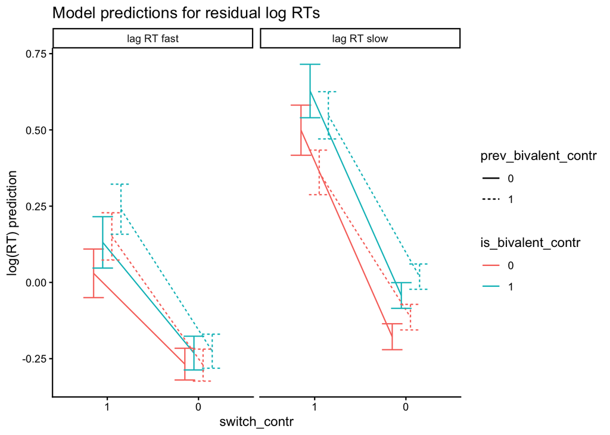

```r
ggplot(preds, aes(x = switch_contr, y = emmean, color = is_bivalent_contr, linetype = prev_bivalent_contr, group = interaction(is_bivalent_contr, prev_bivalent_contr)))+
  geom_line(position = pos)+
  geom_errorbar(aes(ymin = asymp.LCL, ymax = asymp.UCL), position = pos)+
  scale_x_discrete(limits = c("1", "0"))+
  facet_wrap(~speed, labeller = labeller(speed = c("slow" = "lag RT slow",
                                                   "fast" = "lag RT fast")))+
  labs(title = "Model predictions for residual log RTs",
       y = "log(RT) prediction")+
  theme_classic()
```

## 7.3 Helmert-coded cycle variable (we decided to skip!)

### 7.3.1 Effect coded valence (-0.5, 0.5)

#### 7.3.1.1 Removed subject intercepts

```r
alt_cue_rt_log_resrt_prev_helmert_eff <- xfun::cache_rds({
  lmer(time_log_res ~ is_bivalent_eff * prev_bivalent_eff * lag1_time_log_res * cycle_helmert + (is_bivalent_eff + prev_bivalent_eff + lag1_time_log_res + cycle_helmert | id), control = lmerControl(optimizer = "bobyqa"),
       alt_cue %>%
         filter(filter_correct == 0))
}, dir = "dominik/models/", file = "alt_cue_rt_log_resrt_prev_helmert_eff.RDS", rerun = rerun_all)



make_model_table(alt_cue_rt_log_resrt_prev_helmert_eff)

preds <- emmeans::emmeans(alt_cue_rt_log_resrt_prev_helmert_eff, ~ is_bivalent_eff * prev_bivalent_eff * lag1_time_log_res * cycle_helmert, type = "response",
                          at = list(is_bivalent_eff = factor(c(0, 1)),
                                    prev_bivalent_eff = factor(c(0, 1)),
                                    cycle_helmert = factor(c(1, 2, 3)),
                                    lag1_time_log_res = c(-1.5, 1.5))) %>%
  as.data.frame() %>%
  mutate(speed = case_when(lag1_time_log_res == min(lag1_time_log_res) ~ "fast",
                           lag1_time_log_res == max(lag1_time_log_res) ~ "slow") %>% factor())



ggplot(preds, aes(x = cycle_helmert, y = emmean, color = is_bivalent_eff, linetype = prev_bivalent_eff, group = interaction(is_bivalent_eff, prev_bivalent_eff)))+
  geom_line(position = pos)+
  geom_errorbar(aes(ymin = asymp.LCL, ymax = asymp.UCL), position = pos)+
  #scale_x_discrete(limits = c("1", "0"))+
  facet_wrap(~speed, labeller = labeller(speed = c("slow" = "lag RT slow",
                                                   "fast" = "lag RT fast")))+
  labs(title = "Model predictions for residual log RTs",
       y = "log(RT) prediction")+
  theme_classic()
```

#### 7.3.1.2 Added subject intercepts

```r
alt_cue_rt_log_resrt_prev_helmert_eff_w_s_int <- xfun::cache_rds({
  lmer(time_log_res_w_s_int_c ~ is_bivalent_eff * prev_bivalent_eff * lag1_time_log_res_w_s_int_c * cycle_helmert + (is_bivalent_eff + prev_bivalent_eff + lag1_time_log_res_w_s_int_c + cycle_helmert | id), control = lmerControl(optimizer = "bobyqa"),
       alt_cue %>%
         filter(filter_correct == 0))
}, dir = "dominik/models/", file = "alt_cue_rt_log_resrt_prev_helmert_eff_w_s_int.RDS", rerun = rerun_all)

make_model_table(alt_cue_rt_log_resrt_prev_helmert_eff_w_s_int)

preds <- emmeans::emmeans(alt_cue_rt_log_resrt_prev_helmert_eff_w_s_int, ~ is_bivalent_eff * prev_bivalent_eff * lag1_time_log_res_w_s_int_c * cycle_helmert, type = "response",
                          at = list(is_bivalent_eff = factor(c(0, 1)),
                                    prev_bivalent_eff = factor(c(0, 1)),
                                    cycle_helmert = factor(c(1, 2, 3)),
                                    lag1_time_log_res_w_s_int_c = c(-1.5, 1.5))) %>%
  as.data.frame() %>%
  mutate(speed = case_when(lag1_time_log_res_w_s_int_c == min(lag1_time_log_res_w_s_int_c) ~ "fast",
                           lag1_time_log_res_w_s_int_c == max(lag1_time_log_res_w_s_int_c) ~ "slow") %>% factor())



ggplot(preds, aes(x = cycle_helmert, y = emmean, color = is_bivalent_eff, linetype = prev_bivalent_eff, group = interaction(is_bivalent_eff, prev_bivalent_eff)))+
  geom_line(position = pos)+
  geom_errorbar(aes(ymin = asymp.LCL, ymax = asymp.UCL), position = pos)+
  #scale_x_discrete(limits = c("1", "0"))+
  facet_wrap(~speed, labeller = labeller(speed = c("slow" = "lag RT slow",
                                                   "fast" = "lag RT fast")))+
  labs(title = "Model predictions for residual log RTs",
       y = "log(RT) prediction")+
  theme_classic()
```

### 7.3.2 contrast coded valence (0, 1)

#### 7.3.2.1 Removed subject intercepts

```r
alt_cue_rt_log_resrt_prev_helmert_contr <- xfun::cache_rds({
  lmer(time_log_res ~ is_bivalent_contr * prev_bivalent_contr * lag1_time_log_res * cycle_helmert + (is_bivalent_contr + prev_bivalent_contr + lag1_time_log_res + cycle_helmert | id), control = lmerControl(optimizer = "bobyqa"),
       alt_cue %>%
         filter(filter_correct == 0))

}, dir = "dominik/models/", file = "alt_cue_rt_log_resrt_prev_helmert_contr.RDS", rerun = rerun_all)


make_model_table(alt_cue_rt_log_resrt_prev_helmert_contr)



preds <- emmeans::emmeans(alt_cue_rt_log_resrt_prev_helmert_contr, ~ is_bivalent_contr * prev_bivalent_contr * cycle_helmert * lag1_time_log_res, type = "response",
                          at = list(is_bivalent_contr = factor(c(0, 1)),
                                    prev_bivalent_contr = factor(c(0, 1)),
                                    cycle_helmert = factor(c(1, 2, 3)),
                                    lag1_time_log_res = c(-1.5, 1.5))) %>%
  as.data.frame() %>%
  mutate(speed = case_when(lag1_time_log_res == min(lag1_time_log_res) ~ "fast",
                           lag1_time_log_res == max(lag1_time_log_res) ~ "slow") %>% factor())



ggplot(preds, aes(x = cycle_helmert, y = emmean, color = is_bivalent_contr, linetype = prev_bivalent_contr, group = interaction(is_bivalent_contr, prev_bivalent_contr)))+
  geom_line(position = pos)+
  geom_errorbar(aes(ymin = asymp.LCL, ymax = asymp.UCL), position = pos)+
  #scale_x_discrete(limits = c("1", "0"))+
  facet_wrap(~speed, labeller = labeller(speed = c("slow" = "lag RT slow",
                                                   "fast" = "lag RT fast")))+
  labs(title = "Model predictions for residual log RTs",
       y = "log(RT) prediction")+
  theme_classic()
```

#### 7.3.2.2 Added subject intercepts

```r
alt_cue_rt_log_resrt_prev_helmert_contr_w_s_int <- xfun::cache_rds({
  lmer(time_log_res_w_s_int_c ~ is_bivalent_contr * prev_bivalent_contr * lag1_time_log_res_w_s_int_c * cycle_helmert + (is_bivalent_contr + prev_bivalent_contr + lag1_time_log_res_w_s_int_c + cycle_helmert | id), control = lmerControl(optimizer = "bobyqa"),
       alt_cue %>%
         filter(filter_correct == 0))
}, dir = "dominik/models/", file = "alt_cue_rt_log_resrt_prev_helmert_contr_w_s_int.RDS", rerun = rerun_all)


make_model_table(alt_cue_rt_log_resrt_prev_helmert_contr_w_s_int)



preds <- emmeans::emmeans(alt_cue_rt_log_resrt_prev_helmert_contr_w_s_int, ~ is_bivalent_contr * prev_bivalent_contr * cycle_helmert * lag1_time_log_res_w_s_int_c, type = "response",
                          at = list(is_bivalent_contr = factor(c(0, 1)),
                                    prev_bivalent_contr = factor(c(0, 1)),
                                    cycle_helmert = factor(c(1, 2, 3)),
                                    lag1_time_log_res_w_s_int_c = c(-1.5, 1.5))) %>%
  as.data.frame() %>%
  mutate(speed = case_when(lag1_time_log_res_w_s_int_c == min(lag1_time_log_res_w_s_int_c) ~ "fast",
                           lag1_time_log_res_w_s_int_c == max(lag1_time_log_res_w_s_int_c) ~ "slow") %>% factor())



ggplot(preds, aes(x = cycle_helmert, y = emmean, color = is_bivalent_contr, linetype = prev_bivalent_contr, group = interaction(is_bivalent_contr, prev_bivalent_contr)))+
  geom_line(position = pos)+
  geom_errorbar(aes(ymin = asymp.LCL, ymax = asymp.UCL), position = pos)+
  #scale_x_discrete(limits = c("1", "0"))+
  facet_wrap(~speed, labeller = labeller(speed = c("slow" = "lag RT slow",
                                                   "fast" = "lag RT fast")))+
  labs(title = "Model predictions for residual log RTs",
       y = "log(RT) prediction")+
  theme_classic()
```

# 8 Individual differences analysis

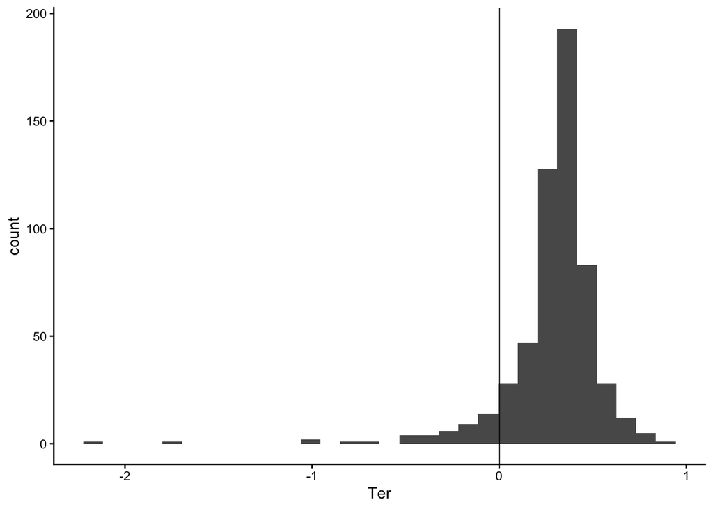

```r
alt_cue_indiv <- alt_cue_agg_ID_ddm_nocycle %>%
  pivot_wider(id_cols = id, names_from = c(is_bivalent_contr, prev_bivalent_contr, switch_contr),
              values_from = c(v, a, Ter, RT_log, Error),
              names_glue = "{.value}_s{switch_contr}_cbiv{is_bivalent_contr}_lbiv{prev_bivalent_contr}") %>%
  ungroup() %>%
  mutate(v_s0_cbiv0_lbiv0_NA = ifelse(Ter_s0_cbiv0_lbiv0 < 0, NA, v_s0_cbiv0_lbiv0),
         v_s0_cbiv0_lbiv1_NA = ifelse(Ter_s0_cbiv0_lbiv1 < 0, NA, v_s0_cbiv0_lbiv1),
         v_s0_cbiv1_lbiv0_NA = ifelse(Ter_s0_cbiv1_lbiv0 < 0, NA, v_s0_cbiv1_lbiv0),
         v_s0_cbiv1_lbiv1_NA = ifelse(Ter_s0_cbiv1_lbiv1 < 0, NA, v_s0_cbiv1_lbiv1),
         v_s1_cbiv0_lbiv0_NA = ifelse(Ter_s1_cbiv0_lbiv0 < 0, NA, v_s1_cbiv0_lbiv0),
         v_s1_cbiv0_lbiv1_NA = ifelse(Ter_s1_cbiv0_lbiv1 < 0, NA, v_s1_cbiv0_lbiv1),
         v_s1_cbiv1_lbiv0_NA = ifelse(Ter_s1_cbiv1_lbiv0 < 0, NA, v_s1_cbiv1_lbiv0),
         v_s1_cbiv1_lbiv1_NA = ifelse(Ter_s1_cbiv1_lbiv1 < 0, NA, v_s1_cbiv1_lbiv1))

alt_cue_agg_ID_ddm_nocycle %>%
  ggplot(aes(x = Ter))+
  geom_histogram()+
  geom_vline(xintercept = 0)+
  theme_classic()
```

```r
alt_cue_agg_ID_ddm_nocycle %>%
  ungroup() %>%
  summarize(N = n(),
            neg_ter = sum(Ter < 0),
            p_neg_Ter = neg_ter/N,
            subjects_w_any_neg_Ter = length(unique(id[Ter < 0])))
```

```
## # A tibble: 1 × 4
##       N neg_ter p_neg_Ter subjects_w_any_neg_Ter
##   <int>   <int>     <dbl>                  <int>
## 1   568      44    0.0775                     22
```

```r
alt_cue_indiv <- alt_cue_indiv %>%
  mutate(across(!id, ~ as.vector(scale(.x)))) %>%
  left_join(alt_cue_cog, by = c("id" = "ID"))
```

## 8.1 Models

```r
alt_cue_indiv_diff_models <- list(
  RT = list(uu1 = lm(RT_log_s1_cbiv0_lbiv0 ~ RT_log_s0_cbiv0_lbiv0, alt_cue_indiv),
            uu2 = lm(RT_log_s1_cbiv0_lbiv0 ~ RT_log_s0_cbiv0_lbiv0 + RT_log_s0_cbiv0_lbiv1, alt_cue_indiv),
            uu3 = lm(RT_log_s1_cbiv0_lbiv0 ~ RT_log_s0_cbiv0_lbiv0 + RT_log_s0_cbiv0_lbiv1 + RT_log_s0_cbiv1_lbiv0, alt_cue_indiv),
            uu4 = lm(RT_log_s1_cbiv0_lbiv0 ~ RT_log_s0_cbiv0_lbiv0 + RT_log_s0_cbiv0_lbiv1 + RT_log_s0_cbiv1_lbiv0 + RT_log_s0_cbiv1_lbiv1, alt_cue_indiv),

            bu1 = lm(RT_log_s1_cbiv1_lbiv0 ~ RT_log_s0_cbiv0_lbiv0, alt_cue_indiv),
            bu2 = lm(RT_log_s1_cbiv1_lbiv0 ~ RT_log_s0_cbiv0_lbiv0 + RT_log_s0_cbiv0_lbiv1, alt_cue_indiv),
            bu3 = lm(RT_log_s1_cbiv1_lbiv0 ~ RT_log_s0_cbiv0_lbiv0 + RT_log_s0_cbiv0_lbiv1 + RT_log_s0_cbiv1_lbiv0, alt_cue_indiv),
            bu4 = lm(RT_log_s1_cbiv1_lbiv0 ~ RT_log_s0_cbiv0_lbiv0 + RT_log_s0_cbiv0_lbiv1 + RT_log_s0_cbiv1_lbiv0 + RT_log_s0_cbiv1_lbiv1, alt_cue_indiv),

            ub1 = lm(RT_log_s1_cbiv0_lbiv1 ~ RT_log_s0_cbiv0_lbiv0, alt_cue_indiv),
            ub2 = lm(RT_log_s1_cbiv0_lbiv1 ~ RT_log_s0_cbiv0_lbiv0 + RT_log_s0_cbiv0_lbiv1, alt_cue_indiv),
            ub3 = lm(RT_log_s1_cbiv0_lbiv1 ~ RT_log_s0_cbiv0_lbiv0 + RT_log_s0_cbiv0_lbiv1 + RT_log_s0_cbiv1_lbiv0, alt_cue_indiv),
            ub4 = lm(RT_log_s1_cbiv0_lbiv1 ~ RT_log_s0_cbiv0_lbiv0 + RT_log_s0_cbiv0_lbiv1 + RT_log_s0_cbiv1_lbiv0 + RT_log_s0_cbiv1_lbiv1, alt_cue_indiv),

            bb1 = lm(RT_log_s1_cbiv1_lbiv1 ~ RT_log_s0_cbiv0_lbiv0, alt_cue_indiv),
            bb2 = lm(RT_log_s1_cbiv1_lbiv1 ~ RT_log_s0_cbiv0_lbiv0 + RT_log_s0_cbiv0_lbiv1, alt_cue_indiv),
            bb3 = lm(RT_log_s1_cbiv1_lbiv1 ~ RT_log_s0_cbiv0_lbiv0 + RT_log_s0_cbiv0_lbiv1 + RT_log_s0_cbiv1_lbiv0, alt_cue_indiv),
            bb4 = lm(RT_log_s1_cbiv1_lbiv1 ~ RT_log_s0_cbiv0_lbiv0 + RT_log_s0_cbiv0_lbiv1 + RT_log_s0_cbiv1_lbiv0 + RT_log_s0_cbiv1_lbiv1, alt_cue_indiv)

  ),

  Error = list(uu1 = lm(Error_s1_cbiv0_lbiv0 ~ Error_s0_cbiv0_lbiv0, alt_cue_indiv),
               uu2 = lm(Error_s1_cbiv0_lbiv0 ~ Error_s0_cbiv0_lbiv0 + Error_s0_cbiv0_lbiv1, alt_cue_indiv),
               uu3 = lm(Error_s1_cbiv0_lbiv0 ~ Error_s0_cbiv0_lbiv0 + Error_s0_cbiv0_lbiv1 + Error_s0_cbiv1_lbiv0, alt_cue_indiv),
               uu4 = lm(Error_s1_cbiv0_lbiv0 ~ Error_s0_cbiv0_lbiv0 + Error_s0_cbiv0_lbiv1 + Error_s0_cbiv1_lbiv0 + Error_s0_cbiv1_lbiv1, alt_cue_indiv),
               bu1 = lm(Error_s1_cbiv1_lbiv0 ~ Error_s0_cbiv0_lbiv0, alt_cue_indiv),
               bu2 = lm(Error_s1_cbiv1_lbiv0 ~ Error_s0_cbiv0_lbiv0 + Error_s0_cbiv0_lbiv1, alt_cue_indiv),
               bu3 = lm(Error_s1_cbiv1_lbiv0 ~ Error_s0_cbiv0_lbiv0 + Error_s0_cbiv0_lbiv1 + Error_s0_cbiv1_lbiv0, alt_cue_indiv),
               bu4 = lm(Error_s1_cbiv1_lbiv0 ~ Error_s0_cbiv0_lbiv0 + Error_s0_cbiv0_lbiv1 + Error_s0_cbiv1_lbiv0 + Error_s0_cbiv1_lbiv1, alt_cue_indiv),
               ub1 = lm(Error_s1_cbiv0_lbiv1 ~ Error_s0_cbiv0_lbiv0, alt_cue_indiv),
               ub2 = lm(Error_s1_cbiv0_lbiv1 ~ Error_s0_cbiv0_lbiv0 + Error_s0_cbiv0_lbiv1, alt_cue_indiv),
               ub3 = lm(Error_s1_cbiv0_lbiv1 ~ Error_s0_cbiv0_lbiv0 + Error_s0_cbiv0_lbiv1 + Error_s0_cbiv1_lbiv0, alt_cue_indiv),
               ub4 = lm(Error_s1_cbiv0_lbiv1 ~ Error_s0_cbiv0_lbiv0 + Error_s0_cbiv0_lbiv1 + Error_s0_cbiv1_lbiv0 + Error_s0_cbiv1_lbiv1, alt_cue_indiv),
               bb1 = lm(Error_s1_cbiv1_lbiv1 ~ Error_s0_cbiv0_lbiv0, alt_cue_indiv),
               bb2 = lm(Error_s1_cbiv1_lbiv1 ~ Error_s0_cbiv0_lbiv0 + Error_s0_cbiv0_lbiv1, alt_cue_indiv),
               bb3 = lm(Error_s1_cbiv1_lbiv1 ~ Error_s0_cbiv0_lbiv0 + Error_s0_cbiv0_lbiv1 + Error_s0_cbiv1_lbiv0, alt_cue_indiv),
               bb4 = lm(Error_s1_cbiv1_lbiv1 ~ Error_s0_cbiv0_lbiv0 + Error_s0_cbiv0_lbiv1 + Error_s0_cbiv1_lbiv0 + Error_s0_cbiv1_lbiv1, alt_cue_indiv)

  ),

  v = list(uu1 = lm(v_s1_cbiv0_lbiv0 ~ v_s0_cbiv0_lbiv0, alt_cue_indiv),
           uu2 = lm(v_s1_cbiv0_lbiv0 ~ v_s0_cbiv0_lbiv0 + v_s0_cbiv0_lbiv1, alt_cue_indiv),
           uu3 = lm(v_s1_cbiv0_lbiv0 ~ v_s0_cbiv0_lbiv0 + v_s0_cbiv0_lbiv1 + v_s0_cbiv1_lbiv0, alt_cue_indiv),
           uu4 = lm(v_s1_cbiv0_lbiv0 ~ v_s0_cbiv0_lbiv0 + v_s0_cbiv0_lbiv1 + v_s0_cbiv1_lbiv0 + v_s0_cbiv1_lbiv1, alt_cue_indiv),
           bu1 = lm(v_s1_cbiv1_lbiv0 ~ v_s0_cbiv0_lbiv0, alt_cue_indiv),
           bu2 = lm(v_s1_cbiv1_lbiv0 ~ v_s0_cbiv0_lbiv0 + v_s0_cbiv0_lbiv1, alt_cue_indiv),
           bu3 = lm(v_s1_cbiv1_lbiv0 ~ v_s0_cbiv0_lbiv0 + v_s0_cbiv0_lbiv1 + v_s0_cbiv1_lbiv0, alt_cue_indiv),
           bu4 = lm(v_s1_cbiv1_lbiv0 ~ v_s0_cbiv0_lbiv0 + v_s0_cbiv0_lbiv1 + v_s0_cbiv1_lbiv0 + v_s0_cbiv1_lbiv1, alt_cue_indiv),
           ub1 = lm(v_s1_cbiv0_lbiv1 ~ v_s0_cbiv0_lbiv0, alt_cue_indiv),
           ub2 = lm(v_s1_cbiv0_lbiv1 ~ v_s0_cbiv0_lbiv0 + v_s0_cbiv0_lbiv1, alt_cue_indiv),
           ub3 = lm(v_s1_cbiv0_lbiv1 ~ v_s0_cbiv0_lbiv0 + v_s0_cbiv0_lbiv1 + v_s0_cbiv1_lbiv0, alt_cue_indiv),
           ub4 = lm(v_s1_cbiv0_lbiv1 ~ v_s0_cbiv0_lbiv0 + v_s0_cbiv0_lbiv1 + v_s0_cbiv1_lbiv0 + v_s0_cbiv1_lbiv1, alt_cue_indiv),
           bb1 = lm(v_s1_cbiv1_lbiv1 ~ v_s0_cbiv0_lbiv0, alt_cue_indiv),
           bb2 = lm(v_s1_cbiv1_lbiv1 ~ v_s0_cbiv0_lbiv0 + v_s0_cbiv0_lbiv1, alt_cue_indiv),
           bb3 = lm(v_s1_cbiv1_lbiv1 ~ v_s0_cbiv0_lbiv0 + v_s0_cbiv0_lbiv1 + v_s0_cbiv1_lbiv0, alt_cue_indiv),
           bb4 = lm(v_s1_cbiv1_lbiv1 ~ v_s0_cbiv0_lbiv0 + v_s0_cbiv0_lbiv1 + v_s0_cbiv1_lbiv0 + v_s0_cbiv1_lbiv1, alt_cue_indiv)

  ),

  v_NA = list(uu1 = lm(v_s1_cbiv0_lbiv0_NA ~ v_s0_cbiv0_lbiv0_NA, alt_cue_indiv),
              uu2 = lm(v_s1_cbiv0_lbiv0_NA ~ v_s0_cbiv0_lbiv0_NA + v_s0_cbiv0_lbiv1_NA, alt_cue_indiv),
              uu3 = lm(v_s1_cbiv0_lbiv0_NA ~ v_s0_cbiv0_lbiv0_NA + v_s0_cbiv0_lbiv1_NA + v_s0_cbiv1_lbiv0_NA, alt_cue_indiv),
              uu4 = lm(v_s1_cbiv0_lbiv0_NA ~ v_s0_cbiv0_lbiv0_NA + v_s0_cbiv0_lbiv1_NA + v_s0_cbiv1_lbiv0_NA + v_s0_cbiv1_lbiv1_NA, alt_cue_indiv),

              bu1 = lm(v_s1_cbiv1_lbiv0_NA ~ v_s0_cbiv0_lbiv0_NA, alt_cue_indiv),
              bu2 = lm(v_s1_cbiv1_lbiv0_NA ~ v_s0_cbiv0_lbiv0_NA + v_s0_cbiv0_lbiv1_NA, alt_cue_indiv),
              bu3 = lm(v_s1_cbiv1_lbiv0_NA ~ v_s0_cbiv0_lbiv0_NA + v_s0_cbiv0_lbiv1_NA + v_s0_cbiv1_lbiv0_NA, alt_cue_indiv),
              bu4 = lm(v_s1_cbiv1_lbiv0_NA ~ v_s0_cbiv0_lbiv0_NA + v_s0_cbiv0_lbiv1_NA + v_s0_cbiv1_lbiv0_NA + v_s0_cbiv1_lbiv1_NA, alt_cue_indiv),

              ub1 = lm(v_s1_cbiv0_lbiv1_NA ~ v_s0_cbiv0_lbiv0_NA, alt_cue_indiv),
              ub2 = lm(v_s1_cbiv0_lbiv1_NA ~ v_s0_cbiv0_lbiv0_NA + v_s0_cbiv0_lbiv1_NA, alt_cue_indiv),
              ub3 = lm(v_s1_cbiv0_lbiv1_NA ~ v_s0_cbiv0_lbiv0_NA + v_s0_cbiv0_lbiv1_NA + v_s0_cbiv1_lbiv0_NA, alt_cue_indiv),
              ub4 = lm(v_s1_cbiv0_lbiv1_NA ~ v_s0_cbiv0_lbiv0_NA + v_s0_cbiv0_lbiv1_NA + v_s0_cbiv1_lbiv0_NA + v_s0_cbiv1_lbiv1_NA, alt_cue_indiv),

              bb1 = lm(v_s1_cbiv1_lbiv1_NA ~ v_s0_cbiv0_lbiv0_NA, alt_cue_indiv),
              bb2 = lm(v_s1_cbiv1_lbiv1_NA ~ v_s0_cbiv0_lbiv0_NA + v_s0_cbiv0_lbiv1_NA, alt_cue_indiv),
              bb3 = lm(v_s1_cbiv1_lbiv1_NA ~ v_s0_cbiv0_lbiv0_NA + v_s0_cbiv0_lbiv1_NA + v_s0_cbiv1_lbiv0_NA, alt_cue_indiv),
              bb4 = lm(v_s1_cbiv1_lbiv1_NA ~ v_s0_cbiv0_lbiv0_NA + v_s0_cbiv0_lbiv1_NA + v_s0_cbiv1_lbiv0_NA + v_s0_cbiv1_lbiv1_NA, alt_cue_indiv)
  )
)
```

## 8.2 RT

```r
RT_comparisons <- lapply(c("uu", "bu", "ub", "bb"), function(x){

  data.frame(model = compare_models(alt_cue_indiv_diff_models$RT, x)$model_names,
             comparison_p = compare_models(alt_cue_indiv_diff_models$RT, x)$comparison$`Pr(>F)`)

}) %>%
  bind_rows() %>%
  mutate(comparison_sig = ifelse(comparison_p < 0.05, 1, 0))


alt_cue_RT_model_summary <- lapply(alt_cue_indiv_diff_models$RT, function(x){
  m_sum <- x %>%
    summary()

  m_sum %>%
    coef() %>%
    as.data.frame() %>%
    mutate(r_sq = m_sum$r.squared,
           r_sq_adj = m_sum$adj.r.squared)


}) %>%
  bind_rows(.id = "model") %>%
  rownames_to_column("coefficient") %>%
  janitor::clean_names() %>%
  left_join(RT_comparisons) %>%
  mutate(coefficient = gsub("\\...[[:digit:]]+", "", coefficient),
         coefficient = gsub("RT_log_", "", coefficient),
         outcome = gsub("[[:digit:]]", "", model),
         outcome = factor(outcome, levels = c("uu", "ub", "bu", "bb")),
         is_sig = ifelse(pr_t < 0.05, 1, 0),
         r_label = as.character(round(r_sq, 2)),
         r_label = gsub("^0.", ".", r_label),
         r_label = case_when(comparison_sig == 1 ~ paste0(r_label, "*"), .default = r_label),
         r_adj_label = as.character(round(r_sq_adj, 2)),
         r_adj_label = gsub("^0.", ".", r_adj_label),
         r_adj_label = case_when(comparison_sig == 1 ~ paste0(r_adj_label, "*"), .default = r_adj_label))
```

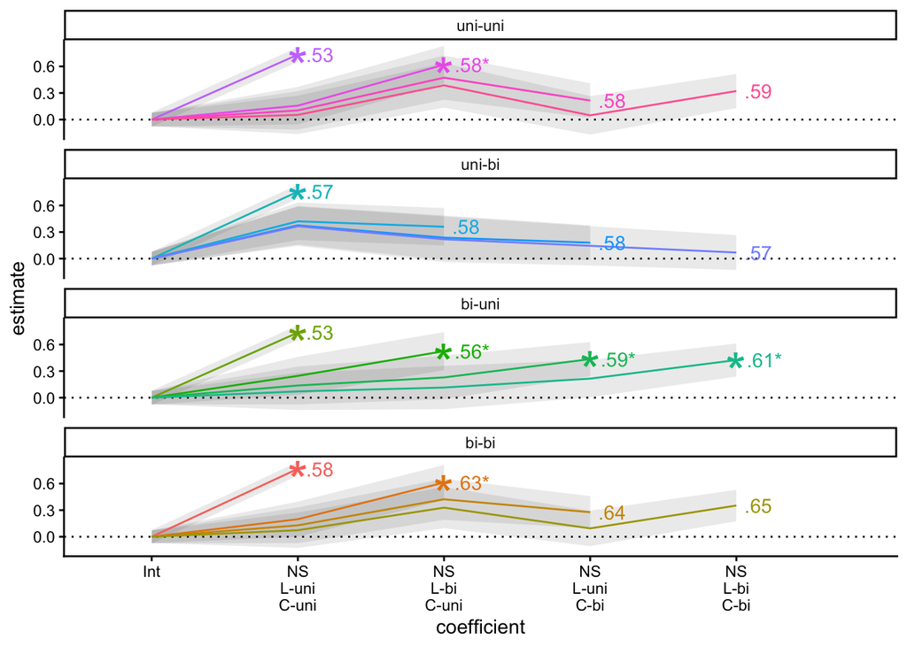

```r
ggplot(alt_cue_RT_model_summary, aes(x = coefficient, y = estimate, group = model, color = model))+
  geom_hline(yintercept = 0, linetype = "dotted")+
  geom_ribbon(aes(ymin = estimate - std_error,
                  ymax = estimate + std_error), alpha = 0.1, color = NA)+
  geom_line()+
  geom_text(data = alt_cue_RT_model_summary %>% group_by(model) %>% slice(n()),
            aes(label = r_adj_label), hjust = -0.3)+
  geom_point(data = alt_cue_RT_model_summary %>% filter(is_sig == 1), pch = "*", size = 10)+
  theme_classic()+
  facet_wrap(~outcome, labeller = labeller(outcome = c("uu" = "uni-uni",
                                                       "bu" = "bi-uni",
                                                       "ub" = "uni-bi",
                                                       "bb" = "bi-bi")),
            ncol = 1)+
  scale_x_discrete(labels = c("s0_cbiv0_lbiv1" = "NS\nL-bi\nC-uni",
                              "s0_cbiv1_lbiv1" = "NS\nL-bi\nC-bi",
                              "s0_cbiv0_lbiv0" = "NS\nL-uni\nC-uni",
                              "s0_cbiv1_lbiv0" = "NS\nL-uni\nC-bi",
                              "(Intercept)" = "Int"))+
  coord_cartesian(xlim = c(1, 5.5))+
  theme(legend.position = "none")
```

### 8.2.1 Model comp: univalent - univalent

```r
compare_models(alt_cue_indiv_diff_models$RT, "uu")$comparison
```

```
## Analysis of Variance Table
##
## Model 1: RT_log_s1_cbiv0_lbiv0 ~ RT_log_s0_cbiv0_lbiv0
## Model 2: RT_log_s1_cbiv0_lbiv0 ~ RT_log_s0_cbiv0_lbiv0 + RT_log_s0_cbiv0_lbiv1
## Model 3: RT_log_s1_cbiv0_lbiv0 ~ RT_log_s0_cbiv0_lbiv0 + RT_log_s0_cbiv0_lbiv1 +
##     RT_log_s0_cbiv1_lbiv0
## Model 4: RT_log_s1_cbiv0_lbiv0 ~ RT_log_s0_cbiv0_lbiv0 + RT_log_s0_cbiv0_lbiv1 +
##     RT_log_s0_cbiv1_lbiv0 + RT_log_s0_cbiv1_lbiv1
##   Res.Df    RSS Df Sum of Sq      F   Pr(>F)
## 1     69 32.361
## 2     68 28.747  1    3.6139 8.8063 0.004179 **
## 3     67 28.239  1    0.5076 1.2369 0.270102
## 4     66 27.085  1    1.1546 2.8135 0.098207 .
## ---
## Signif. codes:  0 '***' 0.001 '**' 0.01 '*' 0.05 '.' 0.1 ' ' 1
```

### 8.2.2 Model comp: univalent - bivalent

```r
compare_models(alt_cue_indiv_diff_models$RT, "ub")$comparison
```

```
## Analysis of Variance Table
##
## Model 1: RT_log_s1_cbiv0_lbiv1 ~ RT_log_s0_cbiv0_lbiv0
## Model 2: RT_log_s1_cbiv0_lbiv1 ~ RT_log_s0_cbiv0_lbiv0 + RT_log_s0_cbiv0_lbiv1
## Model 3: RT_log_s1_cbiv0_lbiv1 ~ RT_log_s0_cbiv0_lbiv0 + RT_log_s0_cbiv0_lbiv1 +
##     RT_log_s0_cbiv1_lbiv0
## Model 4: RT_log_s1_cbiv0_lbiv1 ~ RT_log_s0_cbiv0_lbiv0 + RT_log_s0_cbiv0_lbiv1 +
##     RT_log_s0_cbiv1_lbiv0 + RT_log_s0_cbiv1_lbiv1
##   Res.Df    RSS Df Sum of Sq      F  Pr(>F)
## 1     69 29.975
## 2     68 28.755  1   1.21964 2.8400 0.09666 .
## 3     67 28.396  1   0.35889 0.8357 0.36396
## 4     66 28.343  1   0.05284 0.1230 0.72688
## ---
## Signif. codes:  0 '***' 0.001 '**' 0.01 '*' 0.05 '.' 0.1 ' ' 1
```

### 8.2.3 Model comp: bivalent - univalent

```r
compare_models(alt_cue_indiv_diff_models$RT, "bu")$comparison
```

```
## Analysis of Variance Table
##
## Model 1: RT_log_s1_cbiv1_lbiv0 ~ RT_log_s0_cbiv0_lbiv0
## Model 2: RT_log_s1_cbiv1_lbiv0 ~ RT_log_s0_cbiv0_lbiv0 + RT_log_s0_cbiv0_lbiv1
## Model 3: RT_log_s1_cbiv1_lbiv0 ~ RT_log_s0_cbiv0_lbiv0 + RT_log_s0_cbiv0_lbiv1 +
##     RT_log_s0_cbiv1_lbiv0
## Model 4: RT_log_s1_cbiv1_lbiv0 ~ RT_log_s0_cbiv0_lbiv0 + RT_log_s0_cbiv0_lbiv1 +
##     RT_log_s0_cbiv1_lbiv0 + RT_log_s0_cbiv1_lbiv1
##   Res.Df    RSS Df Sum of Sq      F  Pr(>F)
## 1     69 32.186
## 2     68 29.587  1    2.5992 6.7298 0.01167 *
## 3     67 27.499  1    2.0879 5.4060 0.02315 *
## 4     66 25.491  1    2.0081 5.1994 0.02583 *
## ---
## Signif. codes:  0 '***' 0.001 '**' 0.01 '*' 0.05 '.' 0.1 ' ' 1
```

### 8.2.4 Model comp: bivalent - bivalent

```r
compare_models(alt_cue_indiv_diff_models$RT, "bb")$comparison
```

```
## Analysis of Variance Table
##
## Model 1: RT_log_s1_cbiv1_lbiv1 ~ RT_log_s0_cbiv0_lbiv0
## Model 2: RT_log_s1_cbiv1_lbiv1 ~ RT_log_s0_cbiv0_lbiv0 + RT_log_s0_cbiv0_lbiv1
## Model 3: RT_log_s1_cbiv1_lbiv1 ~ RT_log_s0_cbiv0_lbiv0 + RT_log_s0_cbiv0_lbiv1 +
##     RT_log_s0_cbiv1_lbiv0
## Model 4: RT_log_s1_cbiv1_lbiv1 ~ RT_log_s0_cbiv0_lbiv0 + RT_log_s0_cbiv0_lbiv1 +
##     RT_log_s0_cbiv1_lbiv0 + RT_log_s0_cbiv1_lbiv1
##   Res.Df    RSS Df Sum of Sq       F   Pr(>F)
## 1     69 28.785
## 2     68 25.258  1    3.5269 10.1076 0.002249 **
## 3     67 24.412  1    0.8463  2.4255 0.124158
## 4     66 23.030  1    1.3816  3.9594 0.050755 .
## ---
## Signif. codes:  0 '***' 0.001 '**' 0.01 '*' 0.05 '.' 0.1 ' ' 1
```

## 8.3 Error

```r
Error_comparisons <- lapply(c("uu", "bu", "ub", "bb"), function(x){

  data.frame(model = compare_models(alt_cue_indiv_diff_models$Error, x)$model_names,
             comparison_p = compare_models(alt_cue_indiv_diff_models$Error, x)$comparison$`Pr(>F)`)

}) %>%
  bind_rows() %>%
  mutate(comparison_sig = ifelse(comparison_p < 0.05, 1, 0))


alt_cue_Error_model_summary <- lapply(alt_cue_indiv_diff_models$Error, function(x){
  m_sum <- x %>%
    summary()

  m_sum %>%
    coef() %>%
    as.data.frame() %>%
    mutate(r_sq = m_sum$r.squared,
           r_sq_adj = m_sum$adj.r.squared)
}) %>%
  bind_rows(.id = "model") %>%
  rownames_to_column("coefficient") %>%
  janitor::clean_names() %>%
  left_join(Error_comparisons) %>%
  mutate(coefficient = gsub("\\...[[:digit:]]+", "", coefficient),
         coefficient = gsub("RT_log_", "", coefficient),
         outcome = gsub("[[:digit:]]", "", model),
         outcome = factor(outcome, levels = c("uu", "ub", "bu", "bb")),
         is_sig = ifelse(pr_t < 0.05, 1, 0),
         r_label = as.character(round(r_sq, 2)),
         r_label = gsub("^0.", ".", r_label),
         r_label = case_when(comparison_sig == 1 ~ paste0(r_label, "*"), .default = r_label),
         r_adj_label = as.character(round(r_sq_adj, 2)),
         r_adj_label = gsub("^0.", ".", r_adj_label),
         r_adj_label = case_when(comparison_sig == 1 ~ paste0(r_adj_label, "*"), .default = r_adj_label))
```

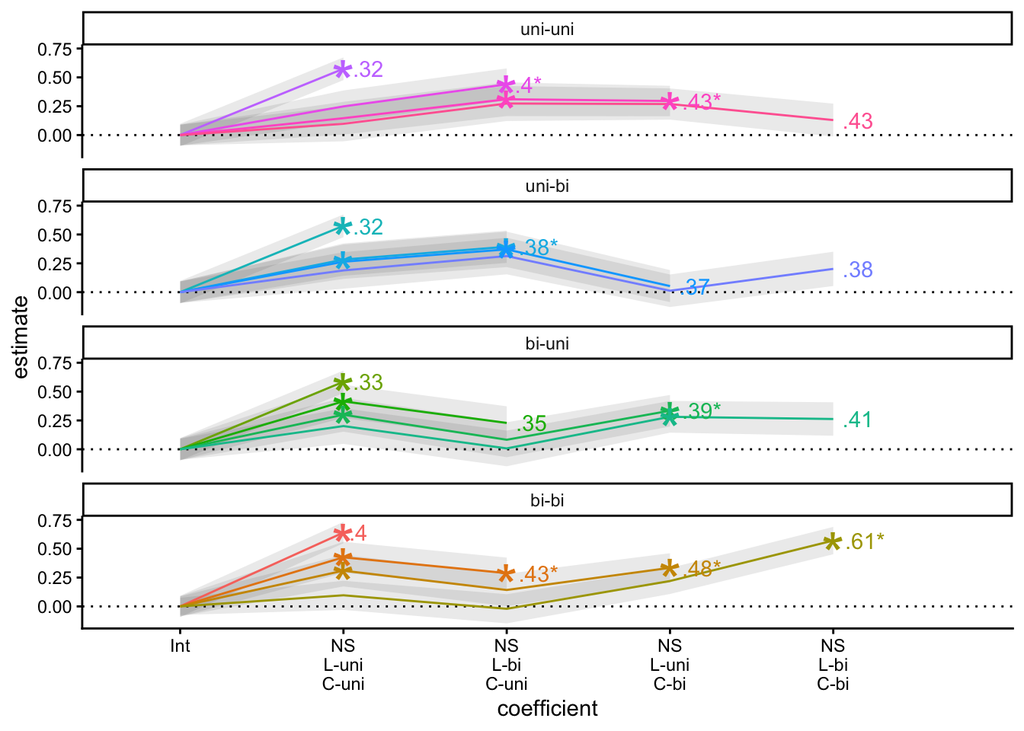

```r
ggplot(alt_cue_Error_model_summary, aes(x = coefficient, y = estimate, group = model, color = model))+
  geom_hline(yintercept = 0, linetype = "dotted")+
  geom_ribbon(aes(ymin = estimate - std_error,
                  ymax = estimate + std_error), alpha = 0.1, color = NA)+
  geom_line()+
  geom_text(data = alt_cue_Error_model_summary %>% group_by(model) %>% slice(n()),
            aes(label = r_adj_label), hjust = -0.3)+
  geom_point(data = alt_cue_Error_model_summary %>% filter(is_sig == 1), pch = "*", size = 10)+
  theme_classic()+
  facet_wrap(~outcome, labeller = labeller(outcome = c("uu" = "uni-uni",
                                                       "bu" = "bi-uni",
                                                       "ub" = "uni-bi",
                                                       "bb" = "bi-bi")),
            ncol = 1)+
  scale_x_discrete(labels = c("Error_s0_cbiv0_lbiv1" = "NS\nL-bi\nC-uni",
                              "Error_s0_cbiv1_lbiv1" = "NS\nL-bi\nC-bi",
                              "Error_s0_cbiv0_lbiv0" = "NS\nL-uni\nC-uni",
                              "Error_s0_cbiv1_lbiv0" = "NS\nL-uni\nC-bi",
                              "(Intercept)" = "Int"))+
  coord_cartesian(xlim = c(1, 5.5))+
  theme(legend.position = "none")
```

### 8.3.1 Model comp: univalent - univalent

```r
compare_models(alt_cue_indiv_diff_models$Error, "uu")$comparison
```

```
## Analysis of Variance Table
##
## Model 1: Error_s1_cbiv0_lbiv0 ~ Error_s0_cbiv0_lbiv0
## Model 2: Error_s1_cbiv0_lbiv0 ~ Error_s0_cbiv0_lbiv0 + Error_s0_cbiv0_lbiv1
## Model 3: Error_s1_cbiv0_lbiv0 ~ Error_s0_cbiv0_lbiv0 + Error_s0_cbiv0_lbiv1 +
##     Error_s0_cbiv1_lbiv0
## Model 4: Error_s1_cbiv0_lbiv0 ~ Error_s0_cbiv0_lbiv0 + Error_s0_cbiv0_lbiv1 +
##     Error_s0_cbiv1_lbiv0 + Error_s0_cbiv1_lbiv1
##   Res.Df    RSS Df Sum of Sq       F   Pr(>F)
## 1     69 46.883
## 2     68 40.815  1    6.0676 10.6752 0.001725 **
## 3     67 37.986  1    2.8291  4.9775 0.029082 *
## 4     66 37.513  1    0.4725  0.8313 0.365215
## ---
## Signif. codes:  0 '***' 0.001 '**' 0.01 '*' 0.05 '.' 0.1 ' ' 1
```

### 8.3.2 Model comp: univalent - bivalent

```r
compare_models(alt_cue_indiv_diff_models$Error, "ub")$comparison
```

```
## Analysis of Variance Table
##
## Model 1: Error_s1_cbiv0_lbiv1 ~ Error_s0_cbiv0_lbiv0
## Model 2: Error_s1_cbiv0_lbiv1 ~ Error_s0_cbiv0_lbiv0 + Error_s0_cbiv0_lbiv1
## Model 3: Error_s1_cbiv0_lbiv1 ~ Error_s0_cbiv0_lbiv0 + Error_s0_cbiv0_lbiv1 +
##     Error_s0_cbiv1_lbiv0
## Model 4: Error_s1_cbiv0_lbiv1 ~ Error_s0_cbiv0_lbiv0 + Error_s0_cbiv0_lbiv1 +
##     Error_s0_cbiv1_lbiv0 + Error_s0_cbiv1_lbiv1
##   Res.Df    RSS Df Sum of Sq      F   Pr(>F)
## 1     69 46.870
## 2     68 41.995  1    4.8752 7.8937 0.006521 **
## 3     67 41.904  1    0.0907 0.1469 0.702746
## 4     66 40.762  1    1.1423 1.8496 0.178461
## ---
## Signif. codes:  0 '***' 0.001 '**' 0.01 '*' 0.05 '.' 0.1 ' ' 1
```

### 8.3.3 Model comp: bivalent - univalent

```r
compare_models(alt_cue_indiv_diff_models$Error, "bu")$comparison
```

```
## Analysis of Variance Table
##
## Model 1: Error_s1_cbiv1_lbiv0 ~ Error_s0_cbiv0_lbiv0
## Model 2: Error_s1_cbiv1_lbiv0 ~ Error_s0_cbiv0_lbiv0 + Error_s0_cbiv0_lbiv1
## Model 3: Error_s1_cbiv1_lbiv0 ~ Error_s0_cbiv0_lbiv0 + Error_s0_cbiv0_lbiv1 +
##     Error_s0_cbiv1_lbiv0
## Model 4: Error_s1_cbiv1_lbiv0 ~ Error_s0_cbiv0_lbiv0 + Error_s0_cbiv0_lbiv1 +
##     Error_s0_cbiv1_lbiv0 + Error_s0_cbiv1_lbiv1
##   Res.Df    RSS Df Sum of Sq      F  Pr(>F)
## 1     69 46.040
## 2     68 44.400  1    1.6407 2.7883 0.09969 .
## 3     67 40.764  1    3.6357 6.1786 0.01547 *
## 4     66 38.837  1    1.9270 3.2748 0.07490 .
## ---
## Signif. codes:  0 '***' 0.001 '**' 0.01 '*' 0.05 '.' 0.1 ' ' 1
```

### 8.3.4 Model comp: bivalent - bivalent

```r
compare_models(alt_cue_indiv_diff_models$Error, "bb")$comparison
```

```
## Analysis of Variance Table
##
## Model 1: Error_s1_cbiv1_lbiv1 ~ Error_s0_cbiv0_lbiv0
## Model 2: Error_s1_cbiv1_lbiv1 ~ Error_s0_cbiv0_lbiv0 + Error_s0_cbiv0_lbiv1
## Model 3: Error_s1_cbiv1_lbiv1 ~ Error_s0_cbiv0_lbiv0 + Error_s0_cbiv0_lbiv1 +
##     Error_s0_cbiv1_lbiv0
## Model 4: Error_s1_cbiv1_lbiv1 ~ Error_s0_cbiv0_lbiv0 + Error_s0_cbiv0_lbiv1 +
##     Error_s0_cbiv1_lbiv0 + Error_s0_cbiv1_lbiv1
##   Res.Df    RSS Df Sum of Sq      F    Pr(>F)
## 1     69 41.347
## 2     68 38.735  1    2.6125  6.634  0.012252 *
## 3     67 35.097  1    3.6379  9.238  0.003396 **
## 4     66 25.991  1    9.1059 23.123 9.164e-06 ***
## ---
## Signif. codes:  0 '***' 0.001 '**' 0.01 '*' 0.05 '.' 0.1 ' ' 1
```

## 8.4 v

```r
v_comparisons <- lapply(c("uu", "bu", "ub", "bb"), function(x){

  data.frame(model = compare_models(alt_cue_indiv_diff_models$v, x)$model_names,
             comparison_p = compare_models(alt_cue_indiv_diff_models$v, x)$comparison$`Pr(>F)`)

}) %>%
  bind_rows() %>%
  mutate(comparison_sig = ifelse(comparison_p < 0.05, 1, 0))



alt_cue_v_model_summary <- lapply(alt_cue_indiv_diff_models$v, function(x){
  m_sum <- x %>%
    summary()

  m_sum %>%
    coef() %>%
    as.data.frame() %>%
    mutate(r_sq = m_sum$r.squared,
           r_sq_adj = m_sum$adj.r.squared)
}) %>%
  bind_rows(.id = "model") %>%
  rownames_to_column("coefficient") %>%
  janitor::clean_names() %>%
  left_join(v_comparisons) %>%
  mutate(coefficient = gsub("\\...[[:digit:]]+", "", coefficient),
         coefficient = gsub("RT_log_", "", coefficient),
         outcome = gsub("[[:digit:]]", "", model),
         outcome = factor(outcome, levels = c("uu", "ub", "bu", "bb")),
         is_sig = ifelse(pr_t < 0.05, 1, 0),
         r_label = as.character(round(r_sq, 2)),
         r_label = gsub("^0.", ".", r_label),
         r_label = case_when(comparison_sig == 1 ~ paste0(r_label, "*"), .default = r_label),
         r_adj_label = as.character(round(r_sq_adj, 2)),
         r_adj_label = gsub("^0.", ".", r_adj_label),
         r_adj_label = case_when(comparison_sig == 1 ~ paste0(r_adj_label, "*"), .default = r_adj_label))
```

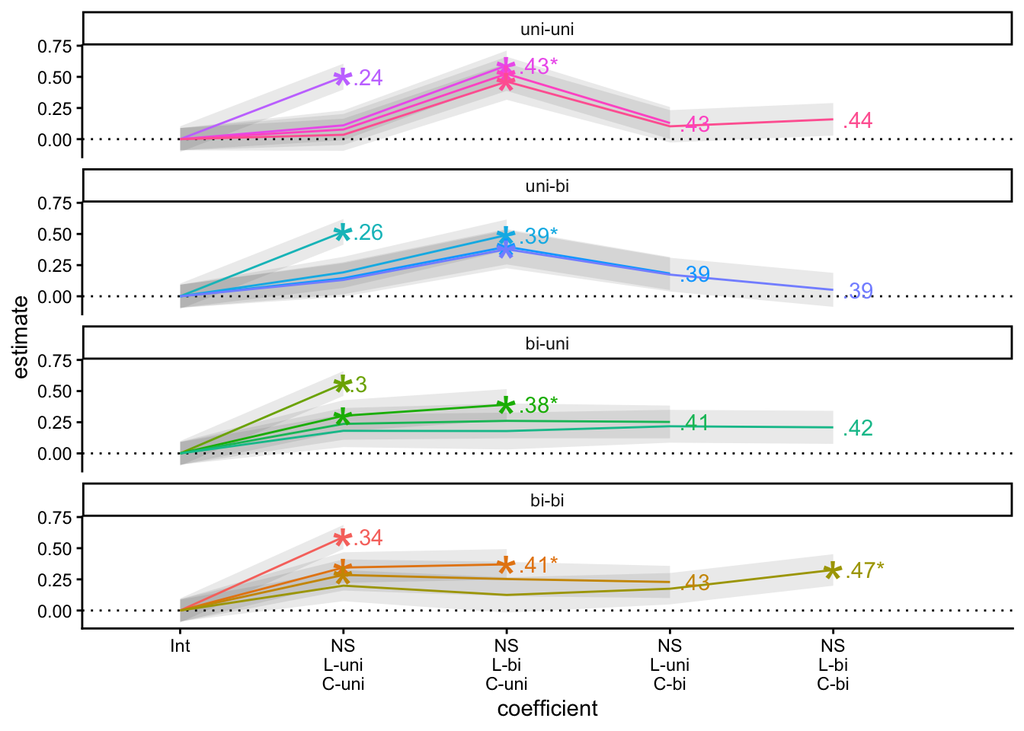

```r
ggplot(alt_cue_v_model_summary, aes(x = coefficient, y = estimate, group = model, color = model))+
  geom_hline(yintercept = 0, linetype = "dotted")+
  geom_ribbon(aes(ymin = estimate - std_error,
                  ymax = estimate + std_error), alpha = 0.1, color = NA)+
  geom_line()+
  geom_text(data = alt_cue_v_model_summary %>% group_by(model) %>% slice(n()),
            aes(label = r_adj_label), hjust = -0.3)+
  geom_point(data = alt_cue_v_model_summary %>% filter(is_sig == 1), pch = "*", size = 10)+
  theme_classic()+
  facet_wrap(~outcome, labeller = labeller(outcome = c("uu" = "uni-uni",
                                                       "bu" = "bi-uni",
                                                       "ub" = "uni-bi",
                                                       "bb" = "bi-bi")),
            ncol = 1)+
  scale_x_discrete(labels = c("v_s0_cbiv0_lbiv1" = "NS\nL-bi\nC-uni",
                              "v_s0_cbiv1_lbiv1" = "NS\nL-bi\nC-bi",
                              "v_s0_cbiv0_lbiv0" = "NS\nL-uni\nC-uni",
                              "v_s0_cbiv1_lbiv0" = "NS\nL-uni\nC-bi",
                              "(Intercept)" = "Int"))+
  coord_cartesian(xlim = c(1, 5.5))+
  theme(legend.position = "none")
```

### 8.4.1 Model comp: univalent - univalent

```r
compare_models(alt_cue_indiv_diff_models$v, "uu")$comparison
```

```
## Analysis of Variance Table
##
## Model 1: v_s1_cbiv0_lbiv0 ~ v_s0_cbiv0_lbiv0
## Model 2: v_s1_cbiv0_lbiv0 ~ v_s0_cbiv0_lbiv0 + v_s0_cbiv0_lbiv1
## Model 3: v_s1_cbiv0_lbiv0 ~ v_s0_cbiv0_lbiv0 + v_s0_cbiv0_lbiv1 + v_s0_cbiv1_lbiv0
## Model 4: v_s1_cbiv0_lbiv0 ~ v_s0_cbiv0_lbiv0 + v_s0_cbiv0_lbiv1 + v_s0_cbiv1_lbiv0 +
##     v_s0_cbiv1_lbiv1
##   Res.Df    RSS Df Sum of Sq       F    Pr(>F)
## 1     69 52.347
## 2     68 38.605  1   13.7425 24.3893 5.652e-06 ***
## 3     67 38.028  1    0.5767  1.0235    0.3154
## 4     66 37.188  1    0.8398  1.4904    0.2265
## ---
## Signif. codes:  0 '***' 0.001 '**' 0.01 '*' 0.05 '.' 0.1 ' ' 1
```

### 8.4.2 Model comp: univalent - bivalent

```r
compare_models(alt_cue_indiv_diff_models$v, "ub")$comparison
```

```
## Analysis of Variance Table
##
## Model 1: v_s1_cbiv0_lbiv1 ~ v_s0_cbiv0_lbiv0
## Model 2: v_s1_cbiv0_lbiv1 ~ v_s0_cbiv0_lbiv0 + v_s0_cbiv0_lbiv1
## Model 3: v_s1_cbiv0_lbiv1 ~ v_s0_cbiv0_lbiv0 + v_s0_cbiv0_lbiv1 + v_s0_cbiv1_lbiv0
## Model 4: v_s1_cbiv0_lbiv1 ~ v_s0_cbiv0_lbiv0 + v_s0_cbiv0_lbiv1 + v_s0_cbiv1_lbiv0 +
##     v_s0_cbiv1_lbiv1
##   Res.Df    RSS Df Sum of Sq       F    Pr(>F)
## 1     69 51.271
## 2     68 41.769  1    9.5025 15.4717 0.0002037 ***
## 3     67 40.624  1    1.1448  1.8639 0.1768123
## 4     66 40.536  1    0.0876  0.1426 0.7068975
## ---
## Signif. codes:  0 '***' 0.001 '**' 0.01 '*' 0.05 '.' 0.1 ' ' 1
```

### 8.4.3 Model comp: bivalent - univalent

```r
compare_models(alt_cue_indiv_diff_models$v, "bu")$comparison
```

```
## Analysis of Variance Table
##
## Model 1: v_s1_cbiv1_lbiv0 ~ v_s0_cbiv0_lbiv0
## Model 2: v_s1_cbiv1_lbiv0 ~ v_s0_cbiv0_lbiv0 + v_s0_cbiv0_lbiv1
## Model 3: v_s1_cbiv1_lbiv0 ~ v_s0_cbiv0_lbiv0 + v_s0_cbiv0_lbiv1 + v_s0_cbiv1_lbiv0
## Model 4: v_s1_cbiv1_lbiv0 ~ v_s0_cbiv0_lbiv0 + v_s0_cbiv0_lbiv1 + v_s0_cbiv1_lbiv0 +
##     v_s0_cbiv1_lbiv1
##   Res.Df    RSS Df Sum of Sq       F   Pr(>F)
## 1     69 47.978
## 2     68 41.957  1    6.0201 10.3672 0.001991 **
## 3     67 39.765  1    2.1921  3.7750 0.056293 .
## 4     66 38.325  1    1.4399  2.4797 0.120107
## ---
## Signif. codes:  0 '***' 0.001 '**' 0.01 '*' 0.05 '.' 0.1 ' ' 1
```

### 8.4.4 Model comp: bivalent - bivalent

```r
compare_models(alt_cue_indiv_diff_models$v, "bb")$comparison
```

```
## Analysis of Variance Table
##
## Model 1: v_s1_cbiv1_lbiv1 ~ v_s0_cbiv0_lbiv0
## Model 2: v_s1_cbiv1_lbiv1 ~ v_s0_cbiv0_lbiv0 + v_s0_cbiv0_lbiv1
## Model 3: v_s1_cbiv1_lbiv1 ~ v_s0_cbiv0_lbiv0 + v_s0_cbiv0_lbiv1 + v_s0_cbiv1_lbiv0
## Model 4: v_s1_cbiv1_lbiv1 ~ v_s0_cbiv0_lbiv0 + v_s0_cbiv0_lbiv1 + v_s0_cbiv1_lbiv0 +
##     v_s0_cbiv1_lbiv1
##   Res.Df    RSS Df Sum of Sq       F   Pr(>F)
## 1     69 45.650
## 2     68 40.253  1    5.3972 10.1901 0.002163 **
## 3     67 38.452  1    1.8011  3.4006 0.069661 .
## 4     66 34.957  1    3.4954  6.5994 0.012470 *
## ---
## Signif. codes:  0 '***' 0.001 '**' 0.01 '*' 0.05 '.' 0.1 ' ' 1
```

## 8.5 v NA

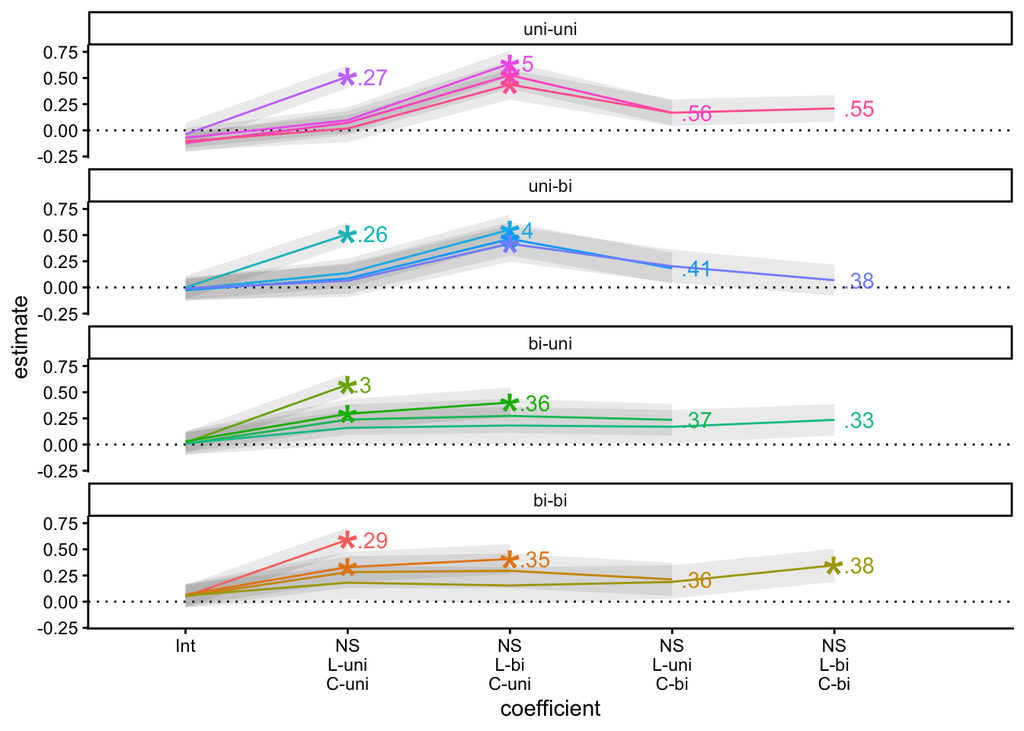

```r
alt_cue_v_NA_model_summary <- lapply(alt_cue_indiv_diff_models$v_NA, function(x){
  m_sum <- x %>%
    summary()

  m_sum %>%
    coef() %>%
    as.data.frame() %>%
    mutate(r_sq = m_sum$r.squared,
           r_sq_adj = m_sum$adj.r.squared)

}) %>%
  bind_rows(.id = "model") %>%
  rownames_to_column("coefficient") %>%
  janitor::clean_names() %>%
  mutate(coefficient = gsub("\\...[[:digit:]]+", "", coefficient),
         coefficient = gsub("v_", "", coefficient),
         coefficient = gsub("_NA", "", coefficient),
         outcome = gsub("[[:digit:]]", "", model),
         outcome = factor(outcome, levels = c("uu", "ub", "bu", "bb")),
         is_sig = ifelse(pr_t < 0.05, 1, 0),
         r_label = as.character(round(r_sq, 2)),
         r_label = gsub("^0.", ".", r_label),
         r_adj_label = as.character(round(r_sq_adj, 2)),
         r_adj_label = gsub("^0.", ".", r_adj_label),
         outcome = factor(outcome, levels = c("uu", "ub", "bu", "bb")))


ggplot(alt_cue_v_NA_model_summary, aes(x = coefficient, y = estimate, group = model, color = model))+
  geom_hline(yintercept = 0, linetype = "dotted")+
  geom_ribbon(aes(ymin = estimate - std_error,
                  ymax = estimate + std_error), alpha = 0.1, color = NA)+
  geom_line()+
  geom_text(data = alt_cue_v_NA_model_summary %>% group_by(model) %>% slice(n()),
            aes(label = r_adj_label), hjust = -0.3)+
  geom_point(data = alt_cue_v_NA_model_summary %>% filter(is_sig == 1), pch = "*", size = 10)+
  theme_classic()+
  facet_wrap(~outcome, labeller = labeller(outcome = c("uu" = "uni-uni",
                                                       "bu" = "bi-uni",
                                                       "ub" = "uni-bi",
                                                       "bb" = "bi-bi")),
            ncol = 1)+
  scale_x_discrete(labels = c("s0_cbiv0_lbiv1" = "NS\nL-bi\nC-uni",
                              "s0_cbiv1_lbiv1" = "NS\nL-bi\nC-bi",
                              "s0_cbiv0_lbiv0" = "NS\nL-uni\nC-uni",
                              "s0_cbiv1_lbiv0" = "NS\nL-uni\nC-bi",
                              "(Intercept)" = "Int"))+
  coord_cartesian(xlim = c(1, 5.5))+
  theme(legend.position = "none")
```

```r
# compare_models(alt_cue_indiv_diff_models$v_NA, "uu")
# compare_models(alt_cue_indiv_diff_models$v_NA, "ub")
# compare_models(alt_cue_indiv_diff_models$v_NA, "bu")
# compare_models(alt_cue_indiv_diff_models$v_NA, "bb")
```